# Project: Supervised Learning - Cars4U - Pre-Owned Car Price Prediction

## Context

There is a huge demand for used cars in the Indian Market today. As sales of new cars have slowed down in the recent past, the pre-owned car market has continued to grow over the past years and is larger than the new car market now. Cars4U is a budding tech start-up that aims to find footholes in this market.

In 2018-19, while new car sales were recorded at 3.6 million units, around 4 million second-hand cars were bought and sold. There is a slowdown in new car sales and that could mean that the demand is shifting towards the pre-owned market. In fact, some car sellers replace their old cars with pre-owned cars instead of buying new ones.

Unlike new cars, where price and supply are fairly deterministic and managed by OEMs (Original Equipment Manufacturer / except for dealership level discounts which come into play only in the last stage of the customer journey), used cars are very different beasts with huge uncertainty in both pricing and supply. Keeping this in mind, the pricing scheme of these used cars becomes important in order to grow in the market.

## Objective

We have to come up with a pricing model that can effectively predict the price of used cars and can help the business in devising profitable strategies using differential pricing. We also need to explore and visualize the dataset, build a linear regression model to predict the prices of used cars, and generate a set of insights and recommendations that will help the business.

## Key Questions

1. What are the key factors influencing the price of a pre-owned cars?
2. Is there a good predictive model for the pre-owned car pricing? What does the performance assessment look like for such a model?

## Data Description

The data contains the different attributes of used cars sold in different locations. The detailed data dictionary is given below.

### Data Dictionary

- S.No.: Serial number
- Name: Name of the car which includes brand name and model name
- Location: Location in which the car is being sold or is available for purchase (cities)
- Year: Manufacturing year of the car
- Kilometers_driven: The total kilometers driven in the car by the previous owner(s) in km
- Fuel_Type: The type of fuel used by the car (Petrol, Diesel, Electric, CNG, LPG)
- Transmission: The type of transmission used by the car (Automatic/Manual)
- Owner: Type of ownership
- Mileage: The standard mileage offered by the car company in kmpl or km/kg
- Engine: The displacement volume of the engine in CC
- Power: The maximum power of the engine in bhp
- Seats: The number of seats in the car
- New_Price: The price of a new car of the same model in INR Lakhs (1 Lakh INR = 100,000 INR)
- Price: The price of the used car in INR Lakhs

## Import necessary libraries and load data

```python
# Libraries to help with reading and manipulating data
import pandas as pd
import numpy as np

# Libraries to help with data visualization
import matplotlib.pyplot as plt
import seaborn as sns
%matplotlib inline

# Removes the limit from the number of displayed columns and rows.
# This is so that we can see the entire dataframe when we print it
pd.set_option('display.max_columns', None)
# pd.set_option('display.max_rows', None)
pd.set_option('display.max_rows', 200)
# We are setting the random seed via np.random.seed so that
# we get the same random results every time
np.random.seed(1)
```

```python
# Use serial number in the CSV as the index instead of auto-generated index
df = pd.read_csv('used_cars_data.csv', index_col=0)
```

```python
print(f'Number of rows: {df.shape[0]} and number of columns: {df.shape[1]}')
```

```
Number of rows: 7253 and number of columns: 13
```

```python
# Check random sample of the data
df.sample(10)
```

| S.No. | Name | Location | Year | Kilometers_Driven | Fuel_Type | Transmission | Owner_Type | Mileage | Engine | Power | Seats | New_Price | Price |
| --- | --- | --- | --- | --- | --- | --- | --- | --- | --- | --- | --- | --- | --- |
| 2397 | Ford EcoSport 1.5 Petrol Trend | Kolkata | 2016 | 21460 | Petrol | Manual | First | 17.0 kmpl | 1497 CC | 121.36 bhp | 5.0 | 9.47 Lakh | 6.00 |
| 3777 | Maruti Wagon R VXI 1.2 | Kochi | 2015 | 49818 | Petrol | Manual | First | 21.5 kmpl | 1197 CC | 81.80 bhp | 5.0 | 5.44 Lakh | 4.11 |
| 4425 | Ford Endeavour 4x2 XLT | Hyderabad | 2007 | 130000 | Diesel | Manual | First | 13.1 kmpl | 2499 CC | 141 bhp | 7.0 | NaN | 6.00 |
| 3661 | Mercedes-Benz E-Class E250 CDI Avantgrade | Coimbatore | 2016 | 39753 | Diesel | Automatic | First | 13.0 kmpl | 2143 CC | 201.1 bhp | 5.0 | NaN | 35.28 |
| 4514 | Hyundai Xcent 1.2 Kappa AT SX Option | Kochi | 2016 | 45560 | Petrol | Automatic | First | 16.9 kmpl | 1197 CC | 82 bhp | 5.0 | NaN | 6.34 |
| 599 | Toyota Innova Crysta 2.8 ZX AT | Coimbatore | 2019 | 40674 | Diesel | Automatic | First | 11.36 kmpl | 2755 CC | 171.5 bhp | 7.0 | 28.05 Lakh | 24.82 |
| 186 | Mercedes-Benz E-Class E250 CDI Avantgrade | Bangalore | 2014 | 37382 | Diesel | Automatic | First | 13.0 kmpl | 2143 CC | 201.1 bhp | 5.0 | NaN | 32.00 |
| 305 | Audi A6 2011-2015 2.0 TDI Premium Plus | Kochi | 2014 | 61726 | Diesel | Automatic | First | 17.68 kmpl | 1968 CC | 174.33 bhp | 5.0 | NaN | 20.77 |
| 4582 | Hyundai i20 1.2 Magna | Kolkata | 2011 | 36000 | Petrol | Manual | First | 18.5 kmpl | 1197 CC | 80 bhp | 5.0 | NaN | 2.50 |
| 5434 | Honda WR-V Edge Edition i-VTEC S | Kochi | 2019 | 13913 | Petrol | Manual | First | 17.5 kmpl | 1199 CC | 88.7 bhp | 5.0 | 9.36 Lakh | 8.20 |

> **Observations**
> - There are both categorical and numerical features
> - Numerical features have units such as Mileage, Engine, Power and New_Price
> - There are missing values in certain columns

```python
# Check for duplicate records if any
df.duplicated().sum()
```

```
1
```

```python
# See the duplicated record
df[df.duplicated()]
```

| S.No. | Name | Location | Year | Kilometers_Driven | Fuel_Type | Transmission | Owner_Type | Mileage | Engine | Power | Seats | New_Price | Price |
| --- | --- | --- | --- | --- | --- | --- | --- | --- | --- | --- | --- | --- | --- |
| 6582 | Honda City 1.5 E MT | Mumbai | 2010 | 52000 | Petrol | Manual | First | 17.0 kmpl | 1497 CC | 118 bhp | 5.0 | NaN | NaN |

> - There is one duplicate row in the data
> - The duplicate row has Price as NaN
> - Both the original and duplicate row will be removed later, since we will be discarding the rows where Price is not avaliable

```python
# checking column names, datatypes and number of non-null values
df.info()
```

```
<class 'pandas.core.frame.DataFrame'>
Int64Index: 7253 entries, 0 to 7252
Data columns (total 13 columns):
 #   Column             Non-Null Count  Dtype
---  ------             --------------  -----
 0   Name               7253 non-null   object
 1   Location           7253 non-null   object
 2   Year               7253 non-null   int64
 3   Kilometers_Driven  7253 non-null   int64
 4   Fuel_Type          7253 non-null   object
 5   Transmission       7253 non-null   object
 6   Owner_Type         7253 non-null   object
 7   Mileage            7251 non-null   object
 8   Engine             7207 non-null   object
 9   Power              7078 non-null   object
 10  Seats              7200 non-null   float64
 11  New_Price          1006 non-null   object
 12  Price              6019 non-null   float64
dtypes: float64(2), int64(2), object(9)
memory usage: 793.3+ KB
```

> - There are missing values for Mileage, Engine, Power, Seats, New_Price and Price columns
> - Majority of the data is missing for New_Price

```python
# Check sum of missing values and their percentages per column
pd.concat([df.isnull().sum().sort_values(), round(df.isnull().sum() * 100/len(df), 2).sort_values()], axis=1)
```

|  | 0 | 1 |
| --- | --- | --- |
| Name | 0 | 0.00 |
| Location | 0 | 0.00 |
| Year | 0 | 0.00 |
| Kilometers_Driven | 0 | 0.00 |
| Fuel_Type | 0 | 0.00 |
| Transmission | 0 | 0.00 |
| Owner_Type | 0 | 0.00 |
| Mileage | 2 | 0.03 |
| Engine | 46 | 0.63 |
| Seats | 53 | 0.73 |
| Power | 175 | 2.41 |
| Price | 1234 | 17.01 |
| New_Price | 6247 | 86.13 |

> - There are missing values for Mileage, Engine, Seats, Power, Price and New_Price columns
> - More than 86% data is missing for New_Price, we may not consider this in our analysis
> - We are going to drop all rows (1234 rows) that has the Price data missing, since that is our target value

```python
# Before doing any modification we would like to keep a backup of our original DataFrame.
df_original = df.copy()
```

```python
# Let's drop the rows where Price is missing. Since it is a Supervised Learning exercise,
# we do not want guess treat missing values of our target variable
df.dropna(subset=['Price'], inplace=True)
```

```python
# Let us reset the dataframe index
df.reset_index(inplace=True, drop=True)
df.head()
```

|  | Name | Location | Year | Kilometers_Driven | Fuel_Type | Transmission | Owner_Type | Mileage | Engine | Power | Seats | New_Price | Price |
| --- | --- | --- | --- | --- | --- | --- | --- | --- | --- | --- | --- | --- | --- |
| 0 | Maruti Wagon R LXI CNG | Mumbai | 2010 | 72000 | CNG | Manual | First | 26.6 km/kg | 998 CC | 58.16 bhp | 5.0 | NaN | 1.75 |
| 1 | Hyundai Creta 1.6 CRDi SX Option | Pune | 2015 | 41000 | Diesel | Manual | First | 19.67 kmpl | 1582 CC | 126.2 bhp | 5.0 | NaN | 12.50 |
| 2 | Honda Jazz V | Chennai | 2011 | 46000 | Petrol | Manual | First | 18.2 kmpl | 1199 CC | 88.7 bhp | 5.0 | 8.61 Lakh | 4.50 |
| 3 | Maruti Ertiga VDI | Chennai | 2012 | 87000 | Diesel | Manual | First | 20.77 kmpl | 1248 CC | 88.76 bhp | 7.0 | NaN | 6.00 |
| 4 | Audi A4 New 2.0 TDI Multitronic | Coimbatore | 2013 | 40670 | Diesel | Automatic | Second | 15.2 kmpl | 1968 CC | 140.8 bhp | 5.0 | NaN | 17.74 |

```python
print(f'After dropping the missing Price rows we have {df.shape[0]} rows.')
```

```
After dropping the missing Price rows we have 6019 rows.
```

```python
# Again check the number of missing values
df.isnull().sum().sort_values(ascending=False)
```

```
New_Price            5195
Power                 143
Seats                  42
Engine                 36
Mileage                 2
Name                    0
Location                0
Year                    0
Kilometers_Driven       0
Fuel_Type               0
Transmission            0
Owner_Type              0
Price                   0
dtype: int64
```

> - There are still missing values for Mileage, Engine, Seats, Power, New_Price columns
> - There are no missing values in Price column any more

```python
# Check the Summary of the data
df.describe(include='all').T.sort_values(by='count')
```

|  | count | unique | top | freq | mean | std | min | 25% | 50% | 75% | max |
| --- | --- | --- | --- | --- | --- | --- | --- | --- | --- | --- | --- |
| New_Price | 824 | 540 | 95.13 Lakh | 6 | NaN | NaN | NaN | NaN | NaN | NaN | NaN |
| Power | 5876 | 371 | 74 bhp | 235 | NaN | NaN | NaN | NaN | NaN | NaN | NaN |
| Seats | 5977.0 | NaN | NaN | NaN | 5.278735 | 0.80884 | 0.0 | 5.0 | 5.0 | 5.0 | 10.0 |
| Engine | 5983 | 146 | 1197 CC | 606 | NaN | NaN | NaN | NaN | NaN | NaN | NaN |
| Mileage | 6017 | 442 | 18.9 kmpl | 172 | NaN | NaN | NaN | NaN | NaN | NaN | NaN |
| Name | 6019 | 1876 | Mahindra XUV500 W8 2WD | 49 | NaN | NaN | NaN | NaN | NaN | NaN | NaN |
| Location | 6019 | 11 | Mumbai | 790 | NaN | NaN | NaN | NaN | NaN | NaN | NaN |
| Year | 6019.0 | NaN | NaN | NaN | 2013.358199 | 3.269742 | 1998.0 | 2011.0 | 2014.0 | 2016.0 | 2019.0 |
| Kilometers_Driven | 6019.0 | NaN | NaN | NaN | 58738.380296 | 91268.843206 | 171.0 | 34000.0 | 53000.0 | 73000.0 | 6500000.0 |
| Fuel_Type | 6019 | 5 | Diesel | 3205 | NaN | NaN | NaN | NaN | NaN | NaN | NaN |
| Transmission | 6019 | 2 | Manual | 4299 | NaN | NaN | NaN | NaN | NaN | NaN | NaN |
| Owner_Type | 6019 | 4 | First | 4929 | NaN | NaN | NaN | NaN | NaN | NaN | NaN |
| Price | 6019.0 | NaN | NaN | NaN | 9.479468 | 11.187917 | 0.44 | 3.5 | 5.64 | 9.95 | 160.0 |

> **Observations**
> - New_Price, Power Engine and Mileage columns are actually numeric but they need to be treated before any analysis
> - Seats has 0s, which does not make sense, we will treat 0 as missing value in this case along with NaNs
> - Similarly for New_Price, Power Engine and Mileage columns, if there are 0s, they will be treated as missing values and we need to find a proper imputation strategy for missing values
> - Name has 1876 unique values and it contians valuable information such as Brand and models, car prices may vary a lot based on its brand and models. We are going to dedicate a section to treat Name column approximately.
> - There are 11 unique Locations, we need to find a strategy to encode them in a simplar way, sometimes Cities or locations does impact car prices to some extent.
> - Fuel_Type, Transmission, Owner_Type are true categorical values. It also shows most of the cars are owned by single owner with manual transmission and runs on diesel.
> - 75% car prices are withing 10L(Lakh) and max value is 160L, the data is highly right-skewed.
> - Kilometers_Driven has certain outliers which exceeds end of life of a car

For each of the categorical variables we would like to check the kind of unique values to make sure, there are no absurd values that would need to be treated as missing values, for this we are not going to discard NaNs if any for now.

```python
cat_cols = ['Location', 'Fuel_Type', 'Transmission', 'Owner_Type', 'Seats']
for col in cat_cols:
    print('>> Domain of: ', col)
    cat = df[col].value_counts(dropna=False).sort_values(ascending=False)
    print(cat)
    print('\n')
```

```
>> Domain of:  Location
Mumbai        790
Hyderabad     742
Kochi         651
Coimbatore    636
Pune          622
Delhi         554
Kolkata       535
Chennai       494
Jaipur        413
Bangalore     358
Ahmedabad     224
Name: Location, dtype: int64


>> Domain of:  Fuel_Type
Diesel      3205
Petrol      2746
CNG           56
LPG           10
Electric       2
Name: Fuel_Type, dtype: int64


>> Domain of:  Transmission
Manual       4299
Automatic    1720
Name: Transmission, dtype: int64


>> Domain of:  Owner_Type
First             4929
Second             968
Third              113
Fourth & Above       9
Name: Owner_Type, dtype: int64


>> Domain of:  Seats
5.0     5014
7.0      674
8.0      134
4.0       99
NaN       42
6.0       31
2.0       16
10.0       5
9.0        3
0.0        1
Name: Seats, dtype: int64
```

> - Location, Fuel_Type, Transmission and Owner_Type values look good.
> - As discussed earlier, Seats have NaNs and 0 values. We would leave Seates as Numeric as it is more of a ordinal value

## Removing the units for Numerical Columns

- New_Price: Convert the New_Price to Lakh only, it has both Lakh and Crores INR units
- Milage, Power, Engine: We need to just remove the units and no translation is required.

```python
def inr_to_num(val):
    """
    Convert a value such as INR 12.5 Lakh or INR 12.5 Cr to Lakh
    Return only the number part as float
    1 Cr = 100 Lakh
    """
    if isinstance(val, str):
        multiplier = 1
        if val.strip().endswith('Lakh'):
            multiplier = 1
        elif val.strip().endswith('Cr'):
            multiplier = 100
        return float(val.replace('Lakh', '').replace('Cr', '').strip()) * multiplier
    else:
        return np.nan
```

```python
# Let's test with some values
print(f"Test for '12.5 Lakh': {inr_to_num('12.5 Lakh')}")
print(f"Test for '12.5 Cr': {inr_to_num('12.5 Cr')}")
print(f"Test for 'NaN': {inr_to_num(np.nan)}")
```

```
Test for '12.5 Lakh': 12.5
Test for '12.5 Cr': 1250.0
Test for 'NaN': nan
```

```python
def str_to_num(val):
    """
    Remove units from values and return just a float number
    Examples: 26.6 km/kg => 26.6 or 126.2 bhp => 126.2 or 1234 CC => 1234.0
    Return only the number as float
    No multiplier or translation is performed.
    """
    if isinstance(val, str):
        num = []
        chars = list(val)
        for c in chars:
            if c.isdigit() or c == '.':
                num.append(c)
        return float(''.join(num))
    else:
        return np.nan
```

```python
# Let's test with some values
print(f"Test for '26.6 km/kg': {str_to_num('26.6 km/kg')}")
print(f"Test for '126.2 bhp': {str_to_num('126.2 bhp')}")
print(f"Test for '1234 CC': {str_to_num('1234 CC')}")
print(f"Test for 'NaN': {str_to_num(np.nan)}")
```

```
Test for '26.6 km/kg': 26.6
Test for '126.2 bhp': 126.2
Test for '1234 CC': 1234.0
Test for 'NaN': nan
```

### Apply the functions to convert columns to numeric

This will now add aditional columns as below

- New_Price -> New_Price_Num
- Mileage -> Mileage_Num
- Power -> Power_Num
- Engine -> Engine_Num

```python
# apply the columm transformations at one go, using a transformation map
col_tran_map = {
    'Mileage': str_to_num,
    'Engine': str_to_num,
    'Power': str_to_num,
    'New_Price': inr_to_num
}

for (k,v) in col_tran_map.items():
    df[k + '_Num'] = df[k].apply(v)

# check the sample of the data
df.sample(10).loc[:,'Mileage': ]
```

|  | Mileage | Engine | Power | Seats | New_Price | Price | Mileage_Num | Engine_Num | Power_Num | New_Price_Num |
| --- | --- | --- | --- | --- | --- | --- | --- | --- | --- | --- |
| 1058 | 18.9 kmpl | 998 CC | 67.1 bhp | 5.0 | NaN | 3.70 | 18.90 | 998.0 | 67.10 | NaN |
| 1502 | 11.74 kmpl | 1796 CC | 186 bhp | 5.0 | NaN | 14.50 | 11.74 | 1796.0 | 186.00 | NaN |
| 3343 | 12.55 kmpl | 2982 CC | 168.5 bhp | 7.0 | NaN | 25.12 | 12.55 | 2982.0 | 168.50 | NaN |
| 5102 | 22.5 kmpl | 998 CC | 67.04 bhp | 5.0 | 5.12 Lakh | 5.34 | 22.50 | 998.0 | 67.04 | 5.12 |
| 3156 | 18.9 kmpl | 1197 CC | 81.86 bhp | 5.0 | 7.98 Lakh | 6.84 | 18.90 | 1197.0 | 81.86 | 7.98 |
| 654 | 24.07 kmpl | 998 CC | 67.1 bhp | 5.0 | 4.7 Lakh | 2.75 | 24.07 | 998.0 | 67.10 | 4.70 |
| 2059 | 33.54 km/kg | 998 CC | 67.04 bhp | 5.0 | 5.58 Lakh | 3.05 | 33.54 | 998.0 | 67.04 | 5.58 |
| 5924 | 15.4 kmpl | 1997 CC | 120 bhp | 7.0 | NaN | 10.08 | 15.40 | 1997.0 | 120.00 | NaN |
| 692 | 20.36 kmpl | 1197 CC | 78.9 bhp | 5.0 | NaN | 2.75 | 20.36 | 1197.0 | 78.90 | NaN |
| 4176 | 19.81 kmpl | 1086 CC | 68.05 bhp | 5.0 | NaN | 3.20 | 19.81 | 1086.0 | 68.05 | NaN |

> As we can see from the sample that numaric transformations have been correctly applied.

```python
# Check the summary stats for newly created numeric columns
df.describe().T
```

|  | count | mean | std | min | 25% | 50% | 75% | max |
| --- | --- | --- | --- | --- | --- | --- | --- | --- |
| Year | 6019.0 | 2013.358199 | 3.269742 | 1998.00 | 2011.0000 | 2014.00 | 2016.00 | 2019.00 |
| Kilometers_Driven | 6019.0 | 58738.380296 | 91268.843206 | 171.00 | 34000.0000 | 53000.00 | 73000.00 | 6500000.00 |
| Seats | 5977.0 | 5.278735 | 0.808840 | 0.00 | 5.0000 | 5.00 | 5.00 | 10.00 |
| Price | 6019.0 | 9.479468 | 11.187917 | 0.44 | 3.5000 | 5.64 | 9.95 | 160.00 |
| Mileage_Num | 6017.0 | 18.134961 | 4.582289 | 0.00 | 15.1700 | 18.15 | 21.10 | 33.54 |
| Engine_Num | 5983.0 | 1621.276450 | 601.355233 | 72.00 | 1198.0000 | 1493.00 | 1984.00 | 5998.00 |
| Power_Num | 5876.0 | 113.253050 | 53.874957 | 34.20 | 75.0000 | 97.70 | 138.10 | 560.00 |
| New_Price_Num | 824.0 | 23.075655 | 26.182412 | 3.91 | 7.9775 | 11.67 | 26.56 | 230.00 |

> - Milage_Num has 0 values in addition to 2 NaNs
> - The other three Engine_Num, Power_Num, New_Price_Num have no 0 or negative values only NaNs

```python
# Now we can drop the original columns that had units in them
df.drop(col_tran_map.keys(), axis=1, inplace=True)
# Check the head of the data to make sure we have all the correct columns
df.head(5)
```

|  | Name | Location | Year | Kilometers_Driven | Fuel_Type | Transmission | Owner_Type | Seats | Price | Mileage_Num | Engine_Num | Power_Num | New_Price_Num |
| --- | --- | --- | --- | --- | --- | --- | --- | --- | --- | --- | --- | --- | --- |
| 0 | Maruti Wagon R LXI CNG | Mumbai | 2010 | 72000 | CNG | Manual | First | 5.0 | 1.75 | 26.60 | 998.0 | 58.16 | NaN |
| 1 | Hyundai Creta 1.6 CRDi SX Option | Pune | 2015 | 41000 | Diesel | Manual | First | 5.0 | 12.50 | 19.67 | 1582.0 | 126.20 | NaN |
| 2 | Honda Jazz V | Chennai | 2011 | 46000 | Petrol | Manual | First | 5.0 | 4.50 | 18.20 | 1199.0 | 88.70 | 8.61 |
| 3 | Maruti Ertiga VDI | Chennai | 2012 | 87000 | Diesel | Manual | First | 7.0 | 6.00 | 20.77 | 1248.0 | 88.76 | NaN |
| 4 | Audi A4 New 2.0 TDI Multitronic | Coimbatore | 2013 | 40670 | Diesel | Automatic | Second | 5.0 | 17.74 | 15.20 | 1968.0 | 140.80 | NaN |

## Split the Name column to Brand and Model

Since the data description says Name consists of Brand name and model name, we can create two columns out of this information, one column for Brand and the model, second for the model variant. Our experience shows that car prices greatly vary based on its brand, model and its variant. Unfortunately there are too many variants, hence we are going to ignore the variant part for now. Also model variant informaiton to some extent encoded in other columns such as Transmission, Seats, Engine and Power features.

From the Name column, it would be sufficient if we capture just Brand and model info and find a grouping strategy to categorize them to reduce the number of distinct values in the set.

```python
def extract_brand_n_model(val):
    """
    Split a car name to its brand-model and variant information
    Return a tuple (brand model, model variant)
    """
    parts = val.split(" ")
    return (" ".join(parts[0:2]), " ".join(parts[2:]))
```

```python
# Test the function with a sample
parts = extract_brand_n_model('Toyota Innova 2.5 GX 7 STR BSIV')
print('Test for [Toyota Innova 2.5 GX 7 STR BSIV] - Brand and Model:', parts[0], ' Model Variant:', parts[1])
```

```
Test for [Toyota Innova 2.5 GX 7 STR BSIV] - Brand and Model: Toyota Innova  Model Variant: 2.5 GX 7 STR BSIV
```

```python
# Add two columns in the dataset based on the Name column
df['Brand_Model'], df['Model_Variant'] = zip(*df['Name'].map(extract_brand_n_model))
```

```python
# Check a sample of the data to see if the Brand_Model and Model_Variant values are correct
df[['Name', 'Brand_Model', 'Model_Variant']].sample(10)
```

|  | Name | Brand_Model | Model_Variant |
| --- | --- | --- | --- |
| 672 | Volkswagen Polo Diesel Highline 1.2L | Volkswagen Polo | Diesel Highline 1.2L |
| 1476 | Mini Cooper Countryman D | Mini Cooper | Countryman D |
| 3766 | Ford Ecosport 1.0 Ecoboost Platinum Edition | Ford Ecosport | 1.0 Ecoboost Platinum Edition |
| 3586 | Maruti Eeco 5 STR With AC Plus HTR CNG | Maruti Eeco | 5 STR With AC Plus HTR CNG |
| 3595 | Maruti Wagon R LX DUO BSIII | Maruti Wagon | R LX DUO BSIII |
| 662 | Volkswagen Vento IPL II Petrol Highline AT | Volkswagen Vento | IPL II Petrol Highline AT |
| 4996 | Honda City 1.5 S MT | Honda City | 1.5 S MT |
| 5540 | Hyundai Creta 1.6 CRDi SX | Hyundai Creta | 1.6 CRDi SX |
| 5290 | Volkswagen Polo 1.5 TDI Highline | Volkswagen Polo | 1.5 TDI Highline |
| 3730 | Audi A4 35 TDI Premium | Audi A4 | 35 TDI Premium |

```python
# Now check the size of the Brand_Model set, we can see there are 216 different Brand and Models
df['Brand_Model'].value_counts(ascending=False)
```

```
Maruti Swift          353
Honda City            270
Hyundai i20           247
Hyundai Verna         170
Toyota Innova         164
                     ...
Fiat Petra              1
Volkswagen Beetle       1
Ambassador Classic      1
Smart Fortwo            1
Jaguar F                1
Name: Brand_Model, Length: 216, dtype: int64
```

```python
# Mean price based on model
brand_model_mean=df.groupby('Brand_Model')['Price'].median().sort_values(ascending=False)
brand_model_mean
```

```
Brand_Model
Lamborghini Gallardo    120.000
Jaguar F                100.000
Mercedes-Benz SLC        68.980
Mercedes-Benz GLS        67.500
Jaguar XJ                66.865
                         ...
Maruti 1000               0.850
Fiat Petra                0.850
Maruti Esteem             0.800
Maruti 800                0.775
Fiat Siena                0.550
Name: Price, Length: 216, dtype: float64
```

```python
def cal_price_range(key):
    """
    Given a Brand and Model type return a custom category based on median price range
    Return P1, P6, P11, etc. where P1 means price within 1 Lakh, P6 means within 6 Lakhs etc.
    """
    val = brand_model_mean[key]
    # We are taking 3 Lakhs as step from one group to the next
    for i in range (1, 125, 3):
        if val <= i:
            return 'P' + str(i)
    return 'P0'
```

```python
# Test with some sample values
print(f"Price range for Lamborghini Gallardo: {cal_price_range('Lamborghini Gallardo')} and for Maruti 800: {cal_price_range('Maruti 800')}" )
```

```
Price range for Lamborghini Gallardo: P121 and for Maruti 800: P1
```

```python
# Add a column for Brand Model Range
df['BM_Range'] = df['Brand_Model'].map(cal_price_range)
```

```python
# Check a sample of ten records
df[['Brand_Model', 'Price', 'BM_Range']].sample(10)
```

|  | Brand_Model | Price | BM_Range |
| --- | --- | --- | --- |
| 440 | Maruti Eeco | 4.70 | P4 |
| 1188 | Hyundai Verna | 5.90 | P7 |
| 956 | Hyundai i20 | 3.70 | P7 |
| 5948 | Skoda Laura | 2.45 | P7 |
| 4967 | Honda Brio | 2.75 | P4 |
| 477 | Ford Figo | 6.80 | P4 |
| 4968 | Tata Tiago | 5.00 | P7 |
| 2348 | Mahindra XUV500 | 8.85 | P10 |
| 693 | Mercedes-Benz SLK-Class | 55.54 | P58 |
| 2846 | Skoda Superb | 5.23 | P10 |

```python
# Unique count of our custom category
len(df['BM_Range'].unique())
```

```
23
```

```python
df['BM_Range'].value_counts().sort_values(ascending=False)
```

```
P7      2633
P4      1420
P10      437
P13      363
P19      337
P25      241
P22      117
P16      106
P37       77
P43       75
P31       73
P34       31
P46       23
P1        20
P28       16
P61       13
P40       12
P58       12
P67        6
P70        4
P64        1
P121       1
P100       1
Name: BM_Range, dtype: int64
```

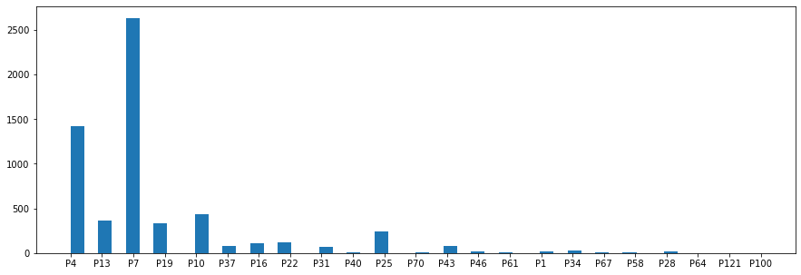

```python
# Below chart shows the count of cars based on our new categorization
fig = plt.figure(figsize=(15,5))
plt.hist(df['BM_Range'], bins=50)
plt.show()
```

Instead of Names column we are going to use this new BM_Range catagory column for our analysis.

## Univariate Analysis, observations and feature engineering

In this section we are going to look at each individual feaures more closely with some visuals and make some data imputations along the way to make the feature more suitable for Linear Regression

```python
# Set sns defualt theme
sns.set_theme()
# function to plot a boxplot and a histogram along the same scale.
def box_hist_plot(data, feature, figsize=(12, 7), bins=10):
    """
    This will show a box and hist plot in a column alignment, For hist plot kde is set to True

    data: dataframe
    feature: dataframe column
    figsize: size of figure (default (12,7))
    """
    # creating the 2 subplots
    f2, (ax_box2, ax_hist2) = plt.subplots(
        nrows=2,  # Number of rows of the subplot grid= 2
        sharex=True,  # x-axis will be shared among all subplots
        gridspec_kw={"height_ratios": (0.25, 0.75)},
        figsize=figsize,
    )
    # boxplot will be created and a star will indicate the mean value of the column
    sns.boxplot(data=data, x=feature, ax=ax_box2, showmeans=True, color="violet")
    # For hist plot
    sns.histplot(data=data, x=feature, kde=True, bins=bins, ax=ax_hist2)
    # Add mean to the histogram
    ax_hist2.axvline(data[feature].mean(), color="green", linestyle="--")
    # Add median to the histogram
    ax_hist2.axvline(data[feature].median(), color="black", linestyle="-")
```

### Analysis of feature: Year

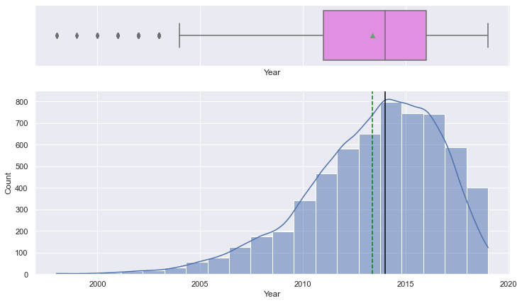

```python
# Draw the box and hist plot of Year
box_hist_plot(df, 'Year', bins=20)
```

```python
# Add column Years_Old by substacting from current year.
df['Years_Old'] = 2021 - df['Year']
# See a sample of data
df[['Name', 'Year', 'Years_Old']].sample(10)
```

|  | Name | Year | Years_Old |
| --- | --- | --- | --- |
| 1001 | Renault KWID RXT Optional | 2018 | 3 |
| 3040 | Maruti Swift VDI | 2015 | 6 |
| 392 | Mercedes-Benz S Class 2005 2013 S 350 CDI | 2017 | 4 |
| 2941 | Hyundai Santro Xing GL Plus LPG | 2014 | 7 |
| 1138 | BMW 5 Series 2013-2017 530d M Sport | 2015 | 6 |
| 4637 | Renault KWID RXT | 2016 | 5 |
| 1061 | Mahindra XUV500 W4 1.99 mHawk | 2017 | 4 |
| 4544 | Maruti Ritz ZXI | 2016 | 5 |
| 4718 | Honda Civic 2006-2010 1.8 S MT | 2009 | 12 |
| 1768 | Hyundai EON 1.0 Kappa Magna Plus Optional | 2014 | 7 |

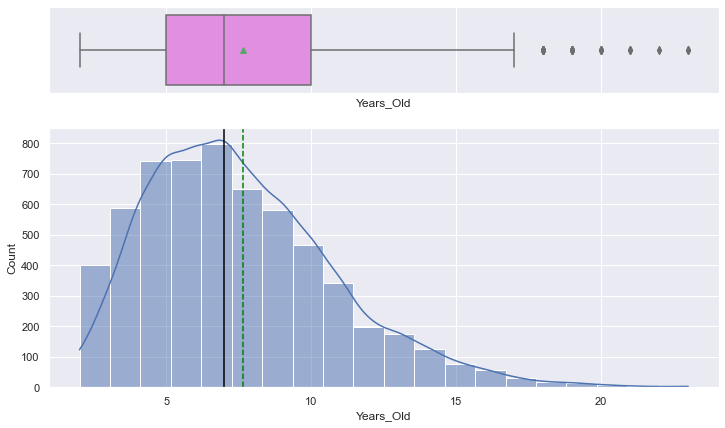

```python
box_hist_plot(df, 'Years_Old', bins=20)
```

### Analysis of feature: Kilometers_Driven

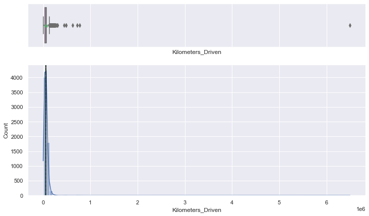

```python
# Draw the box and hist plot of Kilometers_Driven
box_hist_plot(df, 'Kilometers_Driven', bins=100)
```

> - The distribution of Kilometers_Driven is extemely right-skewed
> - The max value is more than 6.5M which seems not correct
> - We know from industry data that a cars end of life is around 300K Miles or cap at 500K kms.
> - Hence we are going to correct these outliers to max 500K

```python
# Check the cars that has KM driven more than 300K
df[df.Kilometers_Driven > 500000]
```

|  | Name | Location | Year | Kilometers_Driven | Fuel_Type | Transmission | Owner_Type | Seats | Price | Mileage_Num | Engine_Num | Power_Num | New_Price_Num | Brand_Model | Model_Variant | BM_Range | Years_Old |
| --- | --- | --- | --- | --- | --- | --- | --- | --- | --- | --- | --- | --- | --- | --- | --- | --- | --- |
| 340 | Skoda Octavia Ambition Plus 2.0 TDI AT | Kolkata | 2013 | 775000 | Diesel | Automatic | First | 5.0 | 7.5 | 19.30 | 1968.0 | 141.0 | NaN | Skoda Octavia | Ambition Plus 2.0 TDI AT | P13 | 8 |
| 358 | Hyundai i10 Magna 1.2 | Chennai | 2009 | 620000 | Petrol | Manual | First | 5.0 | 2.7 | 20.36 | 1197.0 | 78.9 | NaN | Hyundai i10 | Magna 1.2 | P4 | 12 |
| 1860 | Volkswagen Vento Diesel Highline | Chennai | 2013 | 720000 | Diesel | Manual | First | 5.0 | 5.9 | 20.54 | 1598.0 | 103.6 | NaN | Volkswagen Vento | Diesel Highline | P7 | 8 |
| 2328 | BMW X5 xDrive 30d M Sport | Chennai | 2017 | 6500000 | Diesel | Automatic | First | 5.0 | 65.0 | 15.97 | 2993.0 | 258.0 | NaN | BMW X5 | xDrive 30d M Sport | P43 | 4 |

> - We see there are only four cars that have Kilometers_Driven more than 500K
> - For the above rows we will set the kms driven to 500K

```python
# Apply a lambda function to set Kilometers_Driven = 500K where it is more than 500K
df['Kilometers_Driven'] = df['Kilometers_Driven'].apply(lambda val: val if val < 500000 else 500000)
```

```python
# Verify the result, len should be 0
len(df[df.Kilometers_Driven > 500000])
```

```
0
```

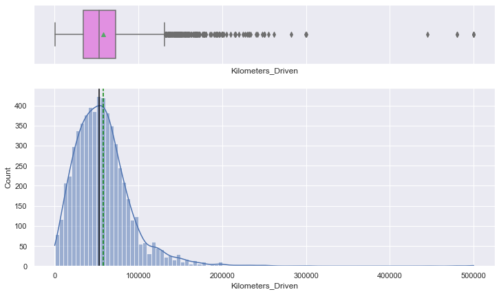

```python
# check the distribution again after removing the outliers
box_hist_plot(df, 'Kilometers_Driven', bins=100)
```

> - Distribution looks much more normalized now but it is still highly right-skewed
> - We would like to see if it gets better after a log transformation

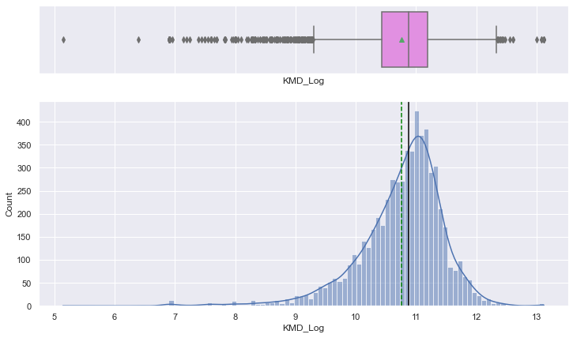

```python
# Check the log normal distribution of the Kilometers_Driven
df['KMD_Log'] = np.log(df['Kilometers_Driven'])
box_hist_plot(df, 'KMD_Log', bins=100)
```

After treating the outliers log transformation does not have much impact other than shifting the skewness from right to left. So we are going to keep the Kilometers_Driven column and apply a StandardScaler to reduce the range of values

```python
# Drop the KMD_Log column
df.drop(['KMD_Log'], axis=1, inplace=True)
```

```python
# Use a standard scaler to reduce the size of values
from sklearn.preprocessing import StandardScaler
std_scaler = StandardScaler()
```

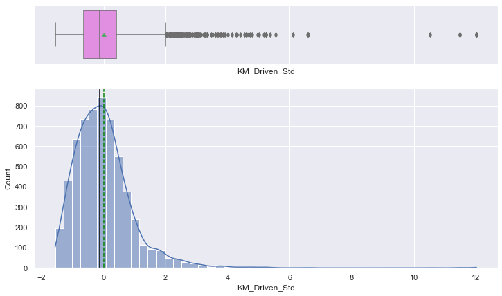

```python
df['KM_Driven_Std'] = std_scaler.fit_transform(df[['Kilometers_Driven']])
box_hist_plot(df, 'KM_Driven_Std', bins=50)
```

### Analysis of feature: Engine_Num

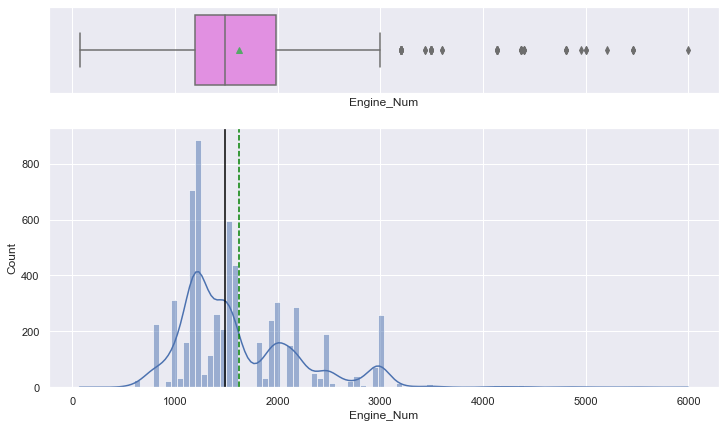

```python
# Draw the box and hist plot of Engine_Num
box_hist_plot(df, 'Engine_Num', bins=100)
```

```python
# cheking the number of missing values in Engine_Num
len(df[df.Engine_Num.isnull()])
```

```
36
```

> - Engine_Num more or less normally distributed but it has right skew
> - Also there are 36 missing values.

The best way to treat the missing value in this case would be pickup a similar cars (make and model) if available and calculate the mean and assign the same to impute the missing value. If no similar car exists then we can resort the the mean of entire column.

The same logic can be applied to impute the missing values for Mileage and Power.

In order to reuse this strategy we are going to write two python functions that will help us to so as follows

```python
# calculate a missing feature based on a similar car or its model
def cal_feature_mean_by_car(feature, name):
    """
    If an exact car name exists in the dataset it will return the mean of those values where the feature is not null
    If the exact car name does not match then it will return the mean of similar car model where the feature is not null
    If that also does not exists then it will return the mean of the feaure
    It return the mean with as float with 2 decimal places

    feature: e.g. Engine_Num
    name: e.g. Maruti Wagon R Vx
    """
    feature_mean_by_name = df[df[feature].notnull() & (df[feature] > 0)].groupby('Name')[feature].mean()
    feature_mean_by_model = df[df[feature].notnull() & (df[feature] > 0)].groupby('Brand_Model')[feature].mean()
    feature_mean = round(df[feature].mean(),2)
    if name in feature_mean_by_name.keys().to_list():
        return round(feature_mean_by_name[name],2)
    else:
        parts = name.split(" ")
        bm = " ".join(parts[0:2])
        if bm in feature_mean_by_model.keys().to_list():
            return round(feature_mean_by_model[bm],2)
        else:
            return feature_mean
```

```python
print("Test for [Toyota Etios Liva V]:", cal_feature_mean_by_car('Engine_Num','Toyota Etios Liva V'))
print("Test for [Maruti Wagon R Vx]:", cal_feature_mean_by_car('Engine_Num','Maruti Wagon R Vx'))
print("Test for [Honda City 1.5 GXI]:", cal_feature_mean_by_car('Engine_Num','Honda City 1.5 GXI'))
print("Test for [NOT Existing]", cal_feature_mean_by_car('Engine_Num','NOT Existing'))
```

```
Test for [Toyota Etios Liva V]: 1197.0
Test for [Maruti Wagon R Vx]: 1014.45
Test for [Honda City 1.5 GXI]: 1493.0
Test for [NOT Existing] 1621.28
```

```python
print(f"Row 191 Name: {df.at[194, 'Name']}, Engine_Num: {df.at[194, 'Engine_Num']}")
print(f"Row 191 Name: {df.at[195, 'Name']}, Engine_Num: {df.at[195, 'Engine_Num']}")
```

```
Row 191 Name: Honda City 1.5 GXI, Engine_Num: nan
Row 191 Name: Honda Amaze S i-Dtech, Engine_Num: 1498.0
```

```python
def impute_zero_or_nan_by_car_mean(feature):
    """
    It takes a feature such as Engine_Num and identify the indexes where its value is 0 or nan
    and then replaces it with mean by calculating using function cal_feature_mean_by_car
    This way it imputes the missing value closest to actual data for the given car
    """
    for idx in df[(df[feature] == 0) | df[feature].isnull()].index.to_list():
        car_name = df.at[idx, 'Name']
        df.at[idx, feature] = cal_feature_mean_by_car(feature, car_name)
        print('Imputed ', feature, ' at ', idx, ' with ', df.at[idx, feature], ' for car ', car_name)
```

```python
impute_zero_or_nan_by_car_mean('Engine_Num')
```

```
Imputed  Engine_Num  at  194  with  1493.0  for car  Honda City 1.5 GXI
Imputed  Engine_Num  at  208  with  1240.47  for car  Maruti Swift 1.3 VXi
Imputed  Engine_Num  at  733  with  1240.47  for car  Maruti Swift 1.3 VXi
Imputed  Engine_Num  at  749  with  2475.72  for car  Land Rover Range Rover 3.0 D
Imputed  Engine_Num  at  1294  with  1494.71  for car  Honda City 1.3 DX
Imputed  Engine_Num  at  1327  with  1240.47  for car  Maruti Swift 1.3 ZXI
Imputed  Engine_Num  at  1385  with  1493.0  for car  Honda City 1.5 GXI
Imputed  Engine_Num  at  1460  with  2475.72  for car  Land Rover Range Rover Sport 2005 2012 Sport
Imputed  Engine_Num  at  2074  with  1240.47  for car  Maruti Swift 1.3 LXI
Imputed  Engine_Num  at  2096  with  1077.42  for car  Hyundai Santro LP zipPlus
Imputed  Engine_Num  at  2264  with  1197.0  for car  Toyota Etios Liva V
Imputed  Engine_Num  at  2325  with  1240.47  for car  Maruti Swift 1.3 VXI ABS
Imputed  Engine_Num  at  2335  with  1240.47  for car  Maruti Swift 1.3 VXi
Imputed  Engine_Num  at  2530  with  2359.43  for car  BMW 5 Series 520d Sedan
Imputed  Engine_Num  at  2542  with  1077.42  for car  Hyundai Santro GLS II - Euro II
Imputed  Engine_Num  at  2623  with  2359.43  for car  BMW 5 Series 520d Sedan
Imputed  Engine_Num  at  2668  with  1240.47  for car  Maruti Swift 1.3 VXi
Imputed  Engine_Num  at  2737  with  1014.45  for car  Maruti Wagon R Vx
Imputed  Engine_Num  at  2780  with  1077.42  for car  Hyundai Santro GLS II - Euro II
Imputed  Engine_Num  at  2842  with  1077.42  for car  Hyundai Santro GLS II - Euro II
Imputed  Engine_Num  at  3272  with  2359.43  for car  BMW 5 Series 520d Sedan
Imputed  Engine_Num  at  3404  with  1240.47  for car  Maruti Swift 1.3 VXi
Imputed  Engine_Num  at  3520  with  2359.43  for car  BMW 5 Series 520d Sedan
Imputed  Engine_Num  at  3522  with  1077.42  for car  Hyundai Santro GLS II - Euro II
Imputed  Engine_Num  at  3810  with  2216.69  for car  Honda CR-V AT With Sun Roof
Imputed  Engine_Num  at  4011  with  1172.0  for car  Fiat Punto 1.3 Emotion
Imputed  Engine_Num  at  4152  with  2475.72  for car  Land Rover Range Rover 3.0 D
Imputed  Engine_Num  at  4229  with  1077.42  for car  Hyundai Santro Xing XG
Imputed  Engine_Num  at  4577  with  2359.43  for car  BMW 5 Series 520d Sedan
Imputed  Engine_Num  at  4604  with  1198.0  for car  Honda Jazz Select Edition
Imputed  Engine_Num  at  4697  with  1172.0  for car  Fiat Punto 1.2 Dynamic
Imputed  Engine_Num  at  4712  with  1077.42  for car  Hyundai Santro Xing XG
Imputed  Engine_Num  at  4952  with  1172.0  for car  Fiat Punto 1.4 Emotion
Imputed  Engine_Num  at  5015  with  1240.47  for car  Maruti Swift 1.3 VXi
Imputed  Engine_Num  at  5185  with  1240.47  for car  Maruti Swift 1.3 LXI
Imputed  Engine_Num  at  5270  with  1493.0  for car  Honda City 1.5 GXI
```

> As we can see from the output, this imputation has nicely taken care of the car brand name and model information

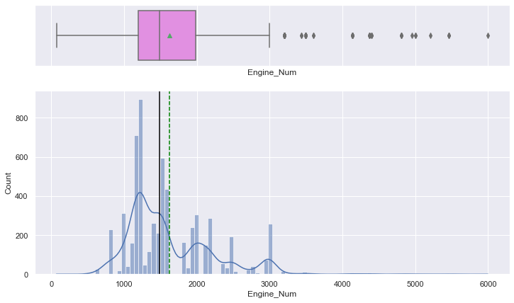

```python
box_hist_plot(df, 'Engine_Num', bins=100)
```

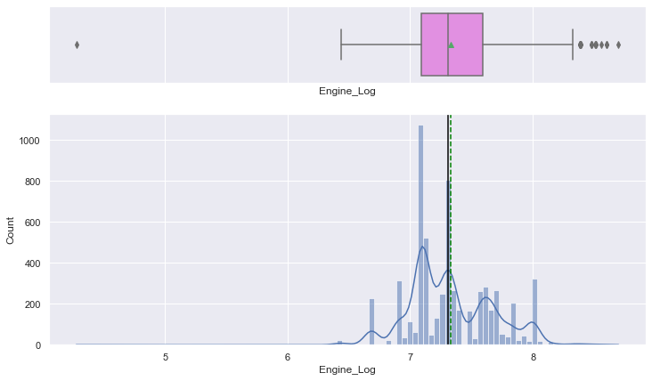

```python
# Let's use log transformation to see if the shape of the data changes
df['Engine_Log'] = np.log(df['Engine_Num'])
box_hist_plot(df, 'Engine_Log', bins=100)
```

> Log transformation has taken care of many outliers and mean and median has come closer to each other. We are going to keep the new column.

### Analysis of feature: Mileage

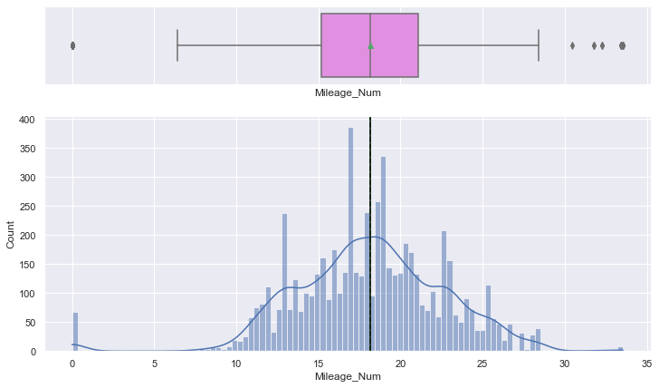

```python
# Draw the box and hist plot of Mileage
box_hist_plot(df, 'Mileage_Num', bins=100)
```

```python
# We noticed that there are 0 and NaN values that need to be imputed
len(df.loc[(df.Mileage_Num == 0) | df.Mileage_Num.isnull()])
```

```
70
```

```python
# Call the same function that was used to treat the missing values for Engine
impute_zero_or_nan_by_car_mean('Mileage_Num')
```

```
Imputed  Mileage_Num  at  14  with  12.89  for car  Land Rover Freelander 2 TD4 SE
Imputed  Mileage_Num  at  67  with  18.14  for car  Mercedes-Benz C-Class Progressive C 220d
Imputed  Mileage_Num  at  79  with  17.2  for car  Hyundai Santro Xing XL
Imputed  Mileage_Num  at  194  with  12.8  for car  Honda City 1.5 GXI
Imputed  Mileage_Num  at  229  with  19.63  for car  Ford Figo Diesel
Imputed  Mileage_Num  at  262  with  17.2  for car  Hyundai Santro Xing XL
Imputed  Mileage_Num  at  307  with  17.2  for car  Hyundai Santro Xing XL
Imputed  Mileage_Num  at  424  with  16.76  for car  Volkswagen Jetta 2007-2011 1.9 L TDI
Imputed  Mileage_Num  at  443  with  17.2  for car  Hyundai Santro GLS I - Euro I
Imputed  Mileage_Num  at  544  with  15.72  for car  Mercedes-Benz New C-Class Progressive C 200
Imputed  Mileage_Num  at  631  with  17.2  for car  Hyundai Santro LS zipPlus
Imputed  Mileage_Num  at  647  with  17.2  for car  Hyundai Santro Xing XP
Imputed  Mileage_Num  at  707  with  12.99  for car  Mercedes-Benz M-Class ML 350 4Matic
Imputed  Mileage_Num  at  749  with  12.89  for car  Land Rover Range Rover 3.0 D
Imputed  Mileage_Num  at  915  with  18.17  for car  Smart Fortwo CDI AT
Imputed  Mileage_Num  at  962  with  18.14  for car  Mercedes-Benz C-Class Progressive C 220d
Imputed  Mileage_Num  at  996  with  17.2  for car  Hyundai Santro Xing GL
Imputed  Mileage_Num  at  1059  with  17.2  for car  Hyundai Santro Xing GL
Imputed  Mileage_Num  at  1259  with  12.89  for car  Land Rover Freelander 2 TD4 S
Imputed  Mileage_Num  at  1271  with  17.2  for car  Hyundai Santro GLS I - Euro II
Imputed  Mileage_Num  at  1308  with  12.99  for car  Mercedes-Benz M-Class ML 350 4Matic
Imputed  Mileage_Num  at  1345  with  22.24  for car  Maruti Baleno Vxi
Imputed  Mileage_Num  at  1354  with  17.2  for car  Hyundai Santro Xing GL
Imputed  Mileage_Num  at  1385  with  12.8  for car  Honda City 1.5 GXI
Imputed  Mileage_Num  at  1419  with  17.2  for car  Hyundai Santro Xing XL
Imputed  Mileage_Num  at  1460  with  12.89  for car  Land Rover Range Rover Sport 2005 2012 Sport
Imputed  Mileage_Num  at  1764  with  12.99  for car  Mercedes-Benz M-Class ML 350 4Matic
Imputed  Mileage_Num  at  1857  with  17.2  for car  Hyundai Santro DX
Imputed  Mileage_Num  at  2053  with  18.21  for car  Mahindra Jeep MM 550 PE
Imputed  Mileage_Num  at  2096  with  17.2  for car  Hyundai Santro LP zipPlus
Imputed  Mileage_Num  at  2130  with  17.2  for car  Hyundai Santro GLS I - Euro II
Imputed  Mileage_Num  at  2267  with  13.1  for car  Toyota Qualis RS E2
Imputed  Mileage_Num  at  2343  with  17.2  for car  Hyundai Santro AT
Imputed  Mileage_Num  at  2542  with  17.2  for car  Hyundai Santro GLS II - Euro II
Imputed  Mileage_Num  at  2597  with  17.2  for car  Hyundai Santro Xing XP
Imputed  Mileage_Num  at  2681  with  14.36  for car  Skoda Superb 3.6 V6 FSI
Imputed  Mileage_Num  at  2780  with  17.2  for car  Hyundai Santro GLS II - Euro II
Imputed  Mileage_Num  at  2842  with  17.2  for car  Hyundai Santro GLS II - Euro II
Imputed  Mileage_Num  at  3033  with  17.2  for car  Hyundai Santro Xing XP
Imputed  Mileage_Num  at  3044  with  17.2  for car  Hyundai Santro Xing GL
```

[output cut: 15 more lines]

```
Imputed  Mileage_Num  at  4704  with  12.99  for car  Mercedes-Benz M-Class ML 350 4Matic
Imputed  Mileage_Num  at  4904  with  18.28  for car  Toyota Prius 2009-2016 Z4
Imputed  Mileage_Num  at  5016  with  12.89  for car  Land Rover Freelander 2 TD4 HSE
Imputed  Mileage_Num  at  5022  with  12.89  for car  Land Rover Freelander 2 TD4 SE
Imputed  Mileage_Num  at  5119  with  17.2  for car  Hyundai Santro Xing XP
Imputed  Mileage_Num  at  5270  with  12.8  for car  Honda City 1.5 GXI
Imputed  Mileage_Num  at  5311  with  12.89  for car  Land Rover Freelander 2 TD4 SE
Imputed  Mileage_Num  at  5374  with  12.99  for car  Mercedes-Benz M-Class ML 350 4Matic
Imputed  Mileage_Num  at  5426  with  17.2  for car  Hyundai Santro Xing XL
Imputed  Mileage_Num  at  5529  with  17.2  for car  Hyundai Santro LP - Euro II
Imputed  Mileage_Num  at  5647  with  13.1  for car  Toyota Qualis Fleet A3
Imputed  Mileage_Num  at  5875  with  18.14  for car  Mercedes-Benz C-Class Progressive C 220d
Imputed  Mileage_Num  at  5943  with  18.21  for car  Mahindra Jeep MM 540 DP
Imputed  Mileage_Num  at  5972  with  17.2  for car  Hyundai Santro Xing GL
Imputed  Mileage_Num  at  6011  with  14.36  for car  Skoda Superb 3.6 V6 FSI
```

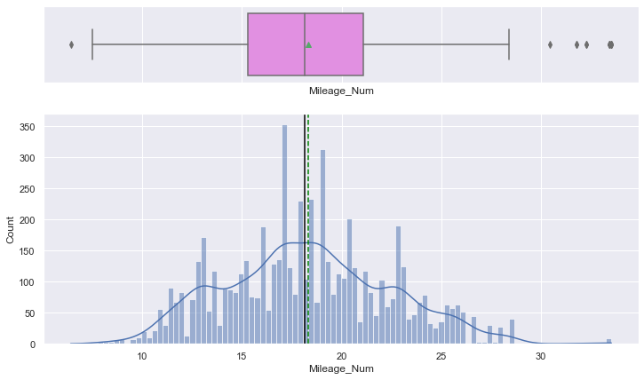

```python
# Draw the box and hist plot of Mileage
box_hist_plot(df, 'Mileage_Num', bins=100)
```

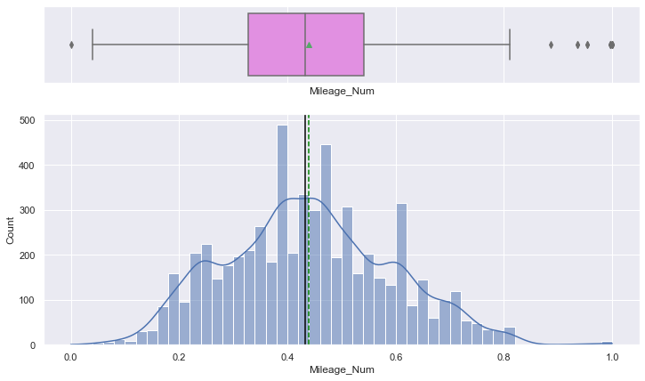

```python
# We will apply MinMaxScaler for reduce the values
from sklearn.preprocessing import MinMaxScaler
df['Mileage_Num'] = MinMaxScaler().fit_transform(df[['Mileage_Num']])
# Draw the box and hist plot of Mileage
box_hist_plot(df, 'Mileage_Num', bins=50)
```

### Analysis of feature: Power

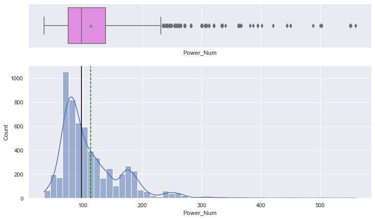

```python
# Draw the box and hist plot of Power
box_hist_plot(df, 'Power_Num', bins=50)
```

> - It has a right skewed distribution
> - A log transformation will help to normalize the data

```python
# Check the number of 0 or missing values
len(df.loc[(df.Power_Num == 0) | df.Power_Num.isnull()])
```

```
143
```

```python
# Call the same function that was used to treat the missing values for Engine
impute_zero_or_nan_by_car_mean('Power_Num')
```

```
Imputed  Power_Num  at  76  with  74.27  for car  Ford Fiesta 1.4 SXi TDCi
Imputed  Power_Num  at  79  with  62.28  for car  Hyundai Santro Xing XL
Imputed  Power_Num  at  89  with  62.28  for car  Hyundai Santro Xing XO
Imputed  Power_Num  at  120  with  62.28  for car  Hyundai Santro Xing XL eRLX Euro III
Imputed  Power_Num  at  143  with  62.28  for car  Hyundai Santro Xing XO eRLX Euro II
Imputed  Power_Num  at  194  with  100.0  for car  Honda City 1.5 GXI
Imputed  Power_Num  at  208  with  77.88  for car  Maruti Swift 1.3 VXi
Imputed  Power_Num  at  227  with  74.0  for car  Maruti Swift VDI BSIV
Imputed  Power_Num  at  245  with  62.28  for car  Hyundai Santro Xing XO eRLX Euro II
Imputed  Power_Num  at  262  with  62.28  for car  Hyundai Santro Xing XL
Imputed  Power_Num  at  307  with  62.28  for car  Hyundai Santro Xing XL
Imputed  Power_Num  at  308  with  74.0  for car  Maruti Swift VDI BSIV
Imputed  Power_Num  at  386  with  62.28  for car  Hyundai Santro Xing XL eRLX Euro III
Imputed  Power_Num  at  424  with  125.79  for car  Volkswagen Jetta 2007-2011 1.9 L TDI
Imputed  Power_Num  at  428  with  62.28  for car  Hyundai Santro Xing XO eRLX Euro II
Imputed  Power_Num  at  443  with  62.28  for car  Hyundai Santro GLS I - Euro I
Imputed  Power_Num  at  472  with  74.27  for car  Ford Fiesta 1.6 SXI ABS Duratec
Imputed  Power_Num  at  575  with  62.28  for car  Hyundai Santro Xing XO
Imputed  Power_Num  at  631  with  62.28  for car  Hyundai Santro LS zipPlus
Imputed  Power_Num  at  647  with  62.28  for car  Hyundai Santro Xing XP
Imputed  Power_Num  at  648  with  67.68  for car  Tata Indica DLS
Imputed  Power_Num  at  733  with  77.88  for car  Maruti Swift 1.3 VXi
Imputed  Power_Num  at  739  with  74.0  for car  Maruti Swift VDI BSIV
Imputed  Power_Num  at  748  with  62.28  for car  Hyundai Santro Xing XO
Imputed  Power_Num  at  749  with  189.6  for car  Land Rover Range Rover 3.0 D
Imputed  Power_Num  at  829  with  78.9  for car  Toyota Etios Liva G
Imputed  Power_Num  at  915  with  113.09  for car  Smart Fortwo CDI AT
Imputed  Power_Num  at  926  with  113.09  for car  Porsche Cayman 2009-2012 S
Imputed  Power_Num  at  934  with  67.05  for car  Toyota Etios GD
Imputed  Power_Num  at  1068  with  67.05  for car  Toyota Etios Liva GD
Imputed  Power_Num  at  1143  with  74.0  for car  Maruti Swift VDI BSIV
Imputed  Power_Num  at  1153  with  62.28  for car  Hyundai Santro Xing XL eRLX Euro III
Imputed  Power_Num  at  1271  with  62.28  for car  Hyundai Santro GLS I - Euro II
Imputed  Power_Num  at  1294  with  110.74  for car  Honda City 1.3 DX
Imputed  Power_Num  at  1319  with  113.05  for car  Fiat Petra 1.2 EL
Imputed  Power_Num  at  1327  with  77.84  for car  Maruti Swift 1.3 ZXI
Imputed  Power_Num  at  1345  with  83.08  for car  Maruti Baleno Vxi
Imputed  Power_Num  at  1385  with  100.0  for car  Honda City 1.5 GXI
Imputed  Power_Num  at  1388  with  74.0  for car  Maruti Swift VDI BSIV
Imputed  Power_Num  at  1419  with  62.28  for car  Hyundai Santro Xing XL
```

[output cut: 88 more lines]

```
Imputed  Power_Num  at  5270  with  100.0  for car  Honda City 1.5 GXI
Imputed  Power_Num  at  5426  with  62.28  for car  Hyundai Santro Xing XL
Imputed  Power_Num  at  5438  with  169.18  for car  Ford Endeavour XLT TDCi 4X4
Imputed  Power_Num  at  5458  with  74.0  for car  Maruti Swift VDI BSIV
Imputed  Power_Num  at  5529  with  62.28  for car  Hyundai Santro LP - Euro II
Imputed  Power_Num  at  5533  with  62.28  for car  Hyundai Santro Xing XO eRLX Euro II
Imputed  Power_Num  at  5647  with  75.0  for car  Toyota Qualis Fleet A3
Imputed  Power_Num  at  5755  with  62.28  for car  Hyundai Santro Xing XL eRLX Euro III
Imputed  Power_Num  at  5759  with  62.28  for car  Hyundai Santro Xing XL eRLX Euro III
Imputed  Power_Num  at  5861  with  62.28  for car  Hyundai Santro Xing XO
Imputed  Power_Num  at  5873  with  62.28  for car  Hyundai Santro Xing XO eRLX Euro II
Imputed  Power_Num  at  5893  with  112.94  for car  Maruti Estilo LXI
Imputed  Power_Num  at  5925  with  122.62  for car  Skoda Laura Classic 1.8 TSI
Imputed  Power_Num  at  5943  with  113.01  for car  Mahindra Jeep MM 540 DP
Imputed  Power_Num  at  5985  with  67.05  for car  Toyota Etios GD
```

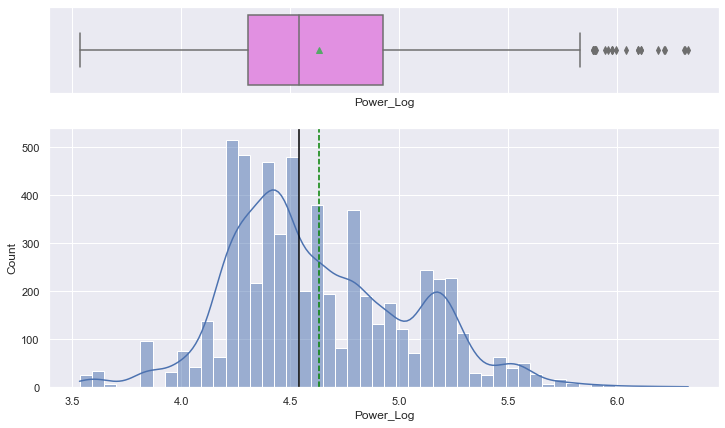

```python
# Apply log transformation to the column
df['Power_Log'] = np.log(df['Power_Num'])
box_hist_plot(df, 'Power_Log',bins=50)
```

### Analysis of feature: New Price

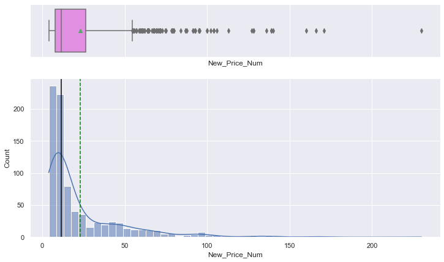

```python
# Draw the box and hist plot of New Price
box_hist_plot(df, 'New_Price_Num', bins=50)
```

> - We already know that New_Price has more than 86% missing values
> - It's distrution is right skewed
> - For now we will transfor it to a log normal distribution but we may have to drop this column

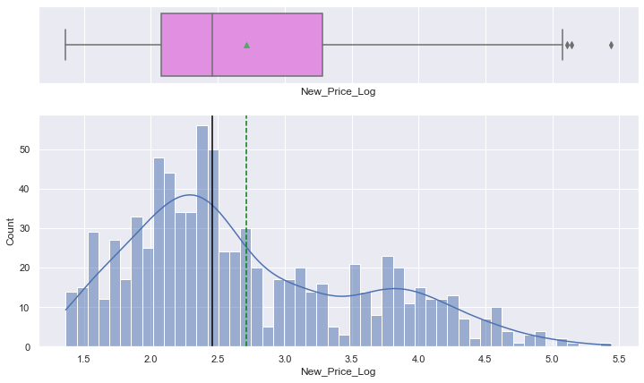

```python
# Apply log transformation
df['New_Price_Log'] = np.log(df['New_Price_Num'])
box_hist_plot(df, 'New_Price_Log',bins=50)
```

### Analysis of feature: Price - The Target Value

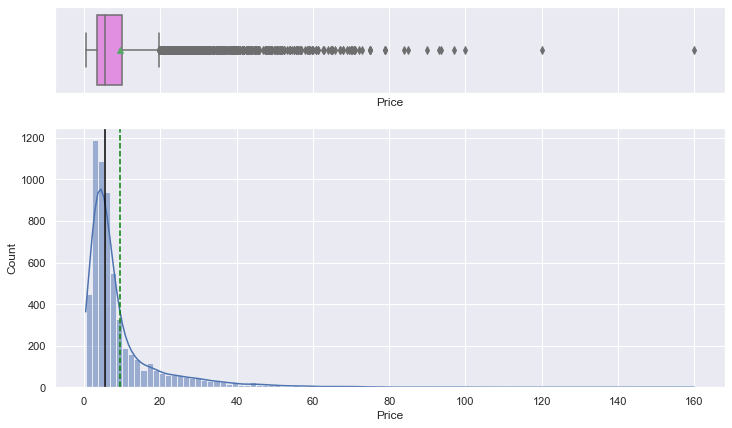

```python
# Draw the box and hist plot of the target price
box_hist_plot(df, 'Price', bins=100)
```

- Price has too many outliers
- Distribution is higly right skewed
- We would not modify this column, since this is the target variable

### Analysis of feature: Seats

For doing analysis of features such as Seats, Location, Owner_Type, Fuel_Type and Tranmission we will create function that will show the counts for each category in order manner with percentage for better understanding.

```python
# function to create bar plot with percent labels
def bar_perc_plot(data, feature):
    """
    Barplot with percentage at the top

    data: dataframe
    feature: dataframe column
    """

    # calculate the fig width dynamically
    total = len(data[feature])
    count = data[feature].nunique()
    plt.figure(figsize=(count + 1, 5))

    plt.xticks(rotation=90, fontsize=15)
    ax = sns.countplot(
        data=data,
        x=feature,
        palette="Paired",
        # Sort the bars from high to low
        order=data[feature].value_counts().sort_values(ascending=False).index,
    )

    for bar in ax.patches:
        # percentage of each class of the category
        label = "{:.2f}%".format(100 * bar.get_height() / total)
        x = bar.get_x() + bar.get_width() / 2  # width of the plot
        y = bar.get_height()  # height of the plot

        # annotate the percentage
        ax.annotate(
            label,
            (x, y),
            ha="center",
            va="center",
            size=12,
            xytext=(0, 5),
            textcoords="offset points",
        )

    plt.show();  # show the plot
```

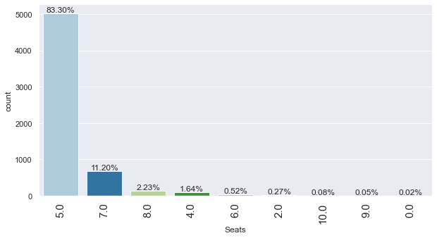

```python
bar_perc_plot(df, 'Seats')
```

```python
# Check the number of rows where Seats is either 0 or NaN
len(df.loc[(df.Seats == 0) | df.Seats.isnull()])
```

```
43
```

```python
# We will impute the missing values in Seats with the mode value which is 5
seat_mode = df.Seats.mode()
seat_mode
```

```
0    5.0
dtype: float64
```

```python
# Impute it with mode value 5
df['Seats'] = df['Seats'].apply(lambda val: val if val > 0 else 5)
```

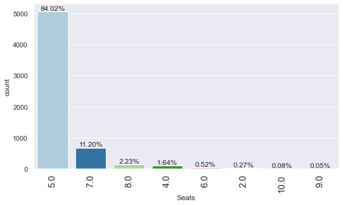

```python
# Now we should see there are no 0 values in the seats
bar_perc_plot(df, 'Seats')
```

### Analysis of feature: Location

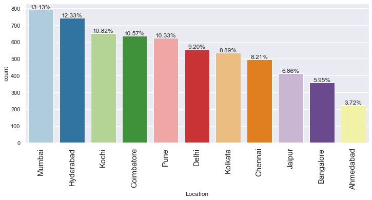

```python
bar_perc_plot(df, 'Location')
```

Sometimes car prices do vary based on a location, the same model may cost little different between Mumbai and Kolkata. We can group these cities based on their median car price range, if a location has higher median prices of cars then generally people in that city are ready to pay little higher prices based on demand and supply situation.

```python
# Calculate the median prices grouped by locations/cities
med_price_zones = df.groupby('Location')['Price'].median().sort_values()
```

```python
med_price_zones
```

```
Location
Kolkata       3.750
Jaipur        4.250
Pune          4.250
Chennai       4.500
Delhi         5.500
Mumbai        5.750
Hyderabad     5.800
Ahmedabad     5.900
Kochi         6.710
Bangalore     6.850
Coimbatore    8.305
Name: Price, dtype: float64
```

```python
def med_price_zone_label(location):
    """
    Given a location return a median price zone

    location: City
    """
    if med_price_zones[location] > 6:
        return 'Median>6L'
    elif 5 < med_price_zones[location] < 6:
        return 'Median5-6L'
    elif 4 < med_price_zones[location] < 5:
        return 'Median4-5L'
    if med_price_zones[location] < 4:
        return 'Median<4L'
```

```python
# Test the function for correctness
med_price_zone_label('Kolkata')
```

```
'Median<4L'
```

```python
# Based on the location we create a new column Med_Price_Zone that encodes every city in one of the four groups
df['Med_Price_Zone'] = df['Location'].map(lambda val: med_price_zone_label(val))
```

```python
# See sample data to verify our change
df.loc[:, ['Location', 'Med_Price_Zone']].head()
```

|  | Location | Med_Price_Zone |
| --- | --- | --- |
| 0 | Mumbai | Median5-6L |
| 1 | Pune | Median4-5L |
| 2 | Chennai | Median4-5L |
| 3 | Chennai | Median4-5L |
| 4 | Coimbatore | Median>6L |

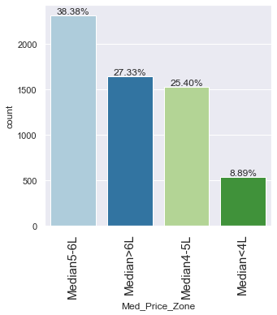

```python
bar_perc_plot(df, 'Med_Price_Zone')
```

### Analysis of feature: Fuel_Type

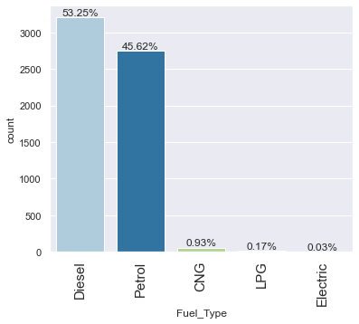

```python
bar_perc_plot(df, 'Fuel_Type')
```

> - Majority of the cars are Diesel cars
> - CNG, LPG and Electic cars consist of just more than 1%

### Analysis of feature: Owner_Type

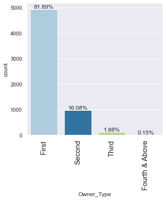

```python
bar_perc_plot(df, 'Owner_Type')
```

> - More than 80% cars are first hand
> - Fourth and above are neglible

### Analysis of feature: Transmission

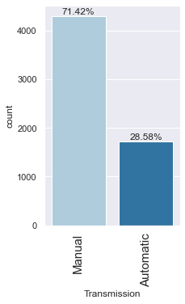

```python
bar_perc_plot(df, 'Transmission')
```

> - More than 70% cars are of manual transmission
> - Recently in India Automatic transmission is catching up
> - Transmission type has become an important factor in car pricing

We are done with our individual feature analysis and engineering. Now lets see the final state of our dataframe. So far we have not dropped any column.

```python
df.info()
```

```
<class 'pandas.core.frame.DataFrame'>
RangeIndex: 6019 entries, 0 to 6018
Data columns (total 22 columns):
 #   Column             Non-Null Count  Dtype
---  ------             --------------  -----
 0   Name               6019 non-null   object
 1   Location           6019 non-null   object
 2   Year               6019 non-null   int64
 3   Kilometers_Driven  6019 non-null   int64
 4   Fuel_Type          6019 non-null   object
 5   Transmission       6019 non-null   object
 6   Owner_Type         6019 non-null   object
 7   Seats              6019 non-null   float64
 8   Price              6019 non-null   float64
 9   Mileage_Num        6019 non-null   float64
 10  Engine_Num         6019 non-null   float64
 11  Power_Num          6019 non-null   float64
 12  New_Price_Num      824 non-null    float64
 13  Brand_Model        6019 non-null   object
 14  Model_Variant      6019 non-null   object
 15  BM_Range           6019 non-null   object
 16  Years_Old          6019 non-null   int64
 17  KM_Driven_Std      6019 non-null   float64
 18  Engine_Log         6019 non-null   float64
 19  Power_Log          6019 non-null   float64
 20  New_Price_Log      824 non-null    float64
 21  Med_Price_Zone     6019 non-null   object
dtypes: float64(10), int64(3), object(9)
memory usage: 1.0+ MB
```

```python
# Take a backup of the dataframe
df2 = df.copy()
# Drop all the columns for which we have added a transformed column
df.drop(['Name', 'Location', 'Year', 'Kilometers_Driven', 'Engine_Num', 'Power_Num', 'New_Price_Num', 'Brand_Model', 'Model_Variant'], axis=1, inplace=True)
```

```python
df.isnull().sum().sort_values(ascending=False)
```

```
New_Price_Log     5195
Fuel_Type            0
Transmission         0
Owner_Type           0
Seats                0
Price                0
Mileage_Num          0
BM_Range             0
Years_Old            0
KM_Driven_Std        0
Engine_Log           0
Power_Log            0
Med_Price_Zone       0
dtype: int64
```

> All columns are looking good except the New_Price_Log. We will remove this after we do correlation analysis of the variable.

## Multivariate Analysis

In this section we would look at the relationships among variables, the best way to check is see the correlation heat map as shown below.

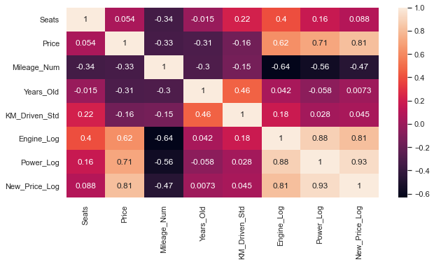

```python
plt.figure(figsize=(10,5))
sns.heatmap(df.corr(), annot=True);
```

- We can see New_Price and Power are highly correlated, also New_Price has more than 86% missing values. Based on these two factors we can take a decision to drop the New_Price column safely.
- Years old and Price has negative correlation which is expected
- Power and Engine are also has high correlation

Since **New_Price_Log** and **Engine_Log** are highly correlated with **Power_Log**, we are going to drop these two columns before feeding the data to the model.

```python
df.drop(['New_Price_Log', 'Engine_Log'], axis=1, inplace=True)
```

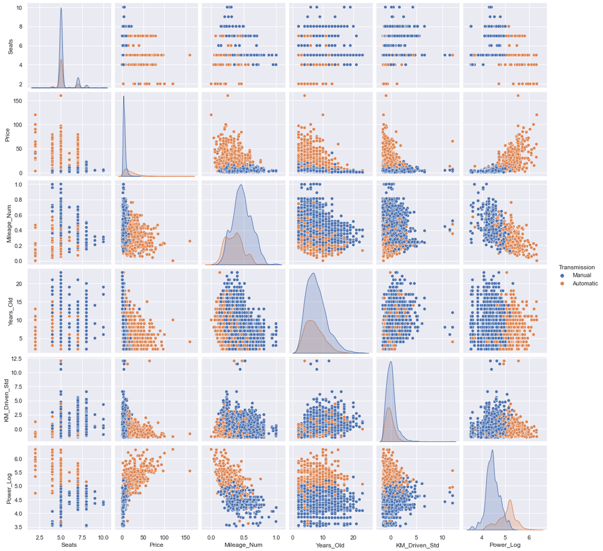

```python
# Check the pair plots of all numerical features group by Transmission
sns.pairplot(df, hue = 'Transmission');
```

> - Interesting to see that Manual and Auto Transmission values take different spaces in the plots
> - Mileage and Power has a slight negative correlation
> - Most of the features seems unrealted to each other

## Model Building

Finally our data preparation is done and we are ready to feed the data to Supervised Learning models. In particular Linear Regression model.

```python
# Final check on missing values for all columns
df.isnull().sum().sort_values(ascending=False)
```

```
Fuel_Type         0
Transmission      0
Owner_Type        0
Seats             0
Price             0
Mileage_Num       0
BM_Range          0
Years_Old         0
KM_Driven_Std     0
Power_Log         0
Med_Price_Zone    0
dtype: int64
```

```python
# Convert the object columns to category to same space
df.info()
```

```
<class 'pandas.core.frame.DataFrame'>
RangeIndex: 6019 entries, 0 to 6018
Data columns (total 11 columns):
 #   Column          Non-Null Count  Dtype
---  ------          --------------  -----
 0   Fuel_Type       6019 non-null   object
 1   Transmission    6019 non-null   object
 2   Owner_Type      6019 non-null   object
 3   Seats           6019 non-null   float64
 4   Price           6019 non-null   float64
 5   Mileage_Num     6019 non-null   float64
 6   BM_Range        6019 non-null   object
 7   Years_Old       6019 non-null   int64
 8   KM_Driven_Std   6019 non-null   float64
 9   Power_Log       6019 non-null   float64
 10  Med_Price_Zone  6019 non-null   object
dtypes: float64(5), int64(1), object(5)
memory usage: 517.4+ KB
```

```python
for col in ['Fuel_Type', 'Transmission', 'Owner_Type', 'BM_Range', 'Med_Price_Zone']:
    df[col] = df[col].astype('category')
df.info()
```

```
<class 'pandas.core.frame.DataFrame'>
RangeIndex: 6019 entries, 0 to 6018
Data columns (total 11 columns):
 #   Column          Non-Null Count  Dtype
---  ------          --------------  -----
 0   Fuel_Type       6019 non-null   category
 1   Transmission    6019 non-null   category
 2   Owner_Type      6019 non-null   category
 3   Seats           6019 non-null   float64
 4   Price           6019 non-null   float64
 5   Mileage_Num     6019 non-null   float64
 6   BM_Range        6019 non-null   category
 7   Years_Old       6019 non-null   int64
 8   KM_Driven_Std   6019 non-null   float64
 9   Power_Log       6019 non-null   float64
 10  Med_Price_Zone  6019 non-null   category
dtypes: category(5), float64(5), int64(1)
memory usage: 313.1 KB
```

```python
# Finally we have 5 category columns and 6 numeric columns
# We'll take a backup of the prepared data
df_prepared=df.copy()
```

> Lets see a sample of the original data and the final prepared data and we can delete all other intermediate frames to save space. Also notice that prepared data size (313 KB) is less than half the size of original data (793KB)

```python
df_original.head()
```

| S.No. | Name | Location | Year | Kilometers_Driven | Fuel_Type | Transmission | Owner_Type | Mileage | Engine | Power | Seats | New_Price | Price |
| --- | --- | --- | --- | --- | --- | --- | --- | --- | --- | --- | --- | --- | --- |
| 0 | Maruti Wagon R LXI CNG | Mumbai | 2010 | 72000 | CNG | Manual | First | 26.6 km/kg | 998 CC | 58.16 bhp | 5.0 | NaN | 1.75 |
| 1 | Hyundai Creta 1.6 CRDi SX Option | Pune | 2015 | 41000 | Diesel | Manual | First | 19.67 kmpl | 1582 CC | 126.2 bhp | 5.0 | NaN | 12.50 |
| 2 | Honda Jazz V | Chennai | 2011 | 46000 | Petrol | Manual | First | 18.2 kmpl | 1199 CC | 88.7 bhp | 5.0 | 8.61 Lakh | 4.50 |
| 3 | Maruti Ertiga VDI | Chennai | 2012 | 87000 | Diesel | Manual | First | 20.77 kmpl | 1248 CC | 88.76 bhp | 7.0 | NaN | 6.00 |
| 4 | Audi A4 New 2.0 TDI Multitronic | Coimbatore | 2013 | 40670 | Diesel | Automatic | Second | 15.2 kmpl | 1968 CC | 140.8 bhp | 5.0 | NaN | 17.74 |

```python
df_prepared.head()
```

|  | Fuel_Type | Transmission | Owner_Type | Seats | Price | Mileage_Num | BM_Range | Years_Old | KM_Driven_Std | Power_Log | Med_Price_Zone |
| --- | --- | --- | --- | --- | --- | --- | --- | --- | --- | --- | --- |
| 0 | CNG | Manual | First | 5.0 | 1.75 | 0.744289 | P4 | 11 | 0.390350 | 4.063198 | Median5-6L |
| 1 | Diesel | Manual | First | 5.0 | 12.50 | 0.488946 | P13 | 6 | -0.452290 | 4.837868 | Median4-5L |
| 2 | Petrol | Manual | First | 5.0 | 4.50 | 0.434783 | P7 | 10 | -0.316380 | 4.485260 | Median4-5L |
| 3 | Diesel | Manual | First | 7.0 | 6.00 | 0.529477 | P7 | 9 | 0.798079 | 4.485936 | Median4-5L |
| 4 | Diesel | Automatic | Second | 5.0 | 17.74 | 0.324245 | P19 | 8 | -0.461260 | 4.947340 | Median>6L |

### Divide the data into Training and Test sets

```python
# Based on the requirement of Supervised Learning, we need to drop the target column from the
# input vector denoted by Xn
X1 = df.drop(["Price"], axis=1)
# yn is the output or predicted variable
y1 = df["Price"]
```

```python
# Creating Dummy Variables, this will perform one hot encoding of all categorical variables and drop the first column
X1 = pd.get_dummies(
    X1,
    columns=X1.select_dtypes(include=["object", "category"]).columns.tolist(),
    drop_first=True,
)

X1.head()
```

|  | Seats | Mileage_Num | Years_Old | KM_Driven_Std | Power_Log | Fuel_Type_Diesel | Fuel_Type_Electric | Fuel_Type_LPG | Fuel_Type_Petrol | Transmission_Manual | Owner_Type_Fourth & Above | Owner_Type_Second | Owner_Type_Third | BM_Range_P10 | BM_Range_P100 | BM_Range_P121 | BM_Range_P13 | BM_Range_P16 | BM_Range_P19 | BM_Range_P22 | BM_Range_P25 | BM_Range_P28 | BM_Range_P31 | BM_Range_P34 | BM_Range_P37 | BM_Range_P4 | BM_Range_P40 | BM_Range_P43 | BM_Range_P46 | … |
| --- | --- | --- | --- | --- | --- | --- | --- | --- | --- | --- | --- | --- | --- | --- | --- | --- | --- | --- | --- | --- | --- | --- | --- | --- | --- | --- | --- | --- | --- | --- |
| 0 | 5.0 | 0.744289 | 11 | 0.390350 | 4.063198 | 0 | 0 | 0 | 0 | 1 | 0 | 0 | 0 | 0 | 0 | 0 | 0 | 0 | 0 | 0 | 0 | 0 | 0 | 0 | 0 | 1 | 0 | 0 | 0 | … |
| 1 | 5.0 | 0.488946 | 6 | -0.452290 | 4.837868 | 1 | 0 | 0 | 0 | 1 | 0 | 0 | 0 | 0 | 0 | 0 | 1 | 0 | 0 | 0 | 0 | 0 | 0 | 0 | 0 | 0 | 0 | 0 | 0 | … |
| 2 | 5.0 | 0.434783 | 10 | -0.316380 | 4.485260 | 0 | 0 | 0 | 1 | 1 | 0 | 0 | 0 | 0 | 0 | 0 | 0 | 0 | 0 | 0 | 0 | 0 | 0 | 0 | 0 | 0 | 0 | 0 | 0 | … |
| 3 | 7.0 | 0.529477 | 9 | 0.798079 | 4.485936 | 1 | 0 | 0 | 0 | 1 | 0 | 0 | 0 | 0 | 0 | 0 | 0 | 0 | 0 | 0 | 0 | 0 | 0 | 0 | 0 | 0 | 0 | 0 | 0 | … |
| 4 | 5.0 | 0.324245 | 8 | -0.461260 | 4.947340 | 1 | 0 | 0 | 0 | 0 | 0 | 1 | 0 | 0 | 0 | 0 | 0 | 0 | 1 | 0 | 0 | 0 | 0 | 0 | 0 | 0 | 0 | 0 | 0 | … |

```python
# Split the data into Train and test set
from sklearn.model_selection import train_test_split

X1_train, X1_test, y1_train, y1_test = train_test_split(X1, y1, test_size=0.3, random_state=1);
```

```python
print('Shape of X1_train: ', X1_train.shape)
print('Shape of X1_test: ', X1_test.shape)
```

```
Shape of X1_train:  (4213, 38)
Shape of X1_test:  (1806, 38)
```

> After performing the one hot encoding of categorical features we now have total 38 columns instead of 11.

### Fit training data to Sklearn LinearRegression

```python
# to build linear regression_model
from sklearn.linear_model import LinearRegression
lin_reg_model = LinearRegression()
lin_reg_model.fit(X1_train, y1_train);
```

```python
coef_df = pd.DataFrame(
    np.append(lin_reg_model.coef_, lin_reg_model.intercept_),
    index=X1_train.columns.tolist() + ["Intercept"],
    columns=["Coefficients"],
)
coef_df.sort_values(by='Coefficients')
```

|  | Coefficients |
| --- | --- |
| Intercept | -9.950300e+00 |
| BM_Range_P7 | -5.721355e+00 |
| BM_Range_P10 | -5.146832e+00 |
| BM_Range_P4 | -4.737877e+00 |
| BM_Range_P13 | -1.723068e+00 |
| Med_Price_Zone_Median<4L | -1.672649e+00 |
| Mileage_Num | -9.206538e-01 |
| Transmission_Manual | -8.941690e-01 |
| KM_Driven_Std | -7.775718e-01 |
| Years_Old | -7.087294e-01 |
| Owner_Type_Second | -6.241994e-01 |
| Med_Price_Zone_Median5-6L | -2.510107e-01 |
| Owner_Type_Third | -3.033533e-02 |
| Fuel_Type_Petrol | -1.417463e-03 |
| BM_Range_P64 | 2.842171e-14 |
| Seats | 1.071978e-01 |
| Owner_Type_Fourth & Above | 4.542642e-01 |
| Med_Price_Zone_Median>6L | 5.434885e-01 |
| BM_Range_P16 | 1.232917e+00 |
| Fuel_Type_Diesel | 1.339392e+00 |
| Fuel_Type_LPG | 1.732027e+00 |
| BM_Range_P19 | 3.087069e+00 |
| BM_Range_P22 | 4.903687e+00 |
| Power_Log | 5.842665e+00 |
| Fuel_Type_Electric | 6.272685e+00 |
| BM_Range_P25 | 6.405809e+00 |
| BM_Range_P28 | 9.512264e+00 |
| BM_Range_P34 | 1.238923e+01 |
| BM_Range_P40 | 1.255439e+01 |
| BM_Range_P31 | 1.303276e+01 |
| BM_Range_P37 | 2.167395e+01 |
| BM_Range_P43 | 2.239640e+01 |
| BM_Range_P46 | 2.838243e+01 |
| BM_Range_P61 | 3.996663e+01 |
| BM_Range_P70 | 4.287938e+01 |
| BM_Range_P67 | 4.468574e+01 |
| BM_Range_P58 | 4.732526e+01 |
| BM_Range_P100 | 7.722933e+01 |
| BM_Range_P121 | 9.905307e+01 |

> **Observations**
> - BM_Range or Cars Brand and Model has significant contribution on the pricing of a Car.
> - Higher the BM_Range category higher the price, specially for very high ranges such as P25 above.
> - P7, P10, P4, P13 range negativly impacts the car price. This may be due to higher supply for these range of cars as the data show that most of the cars fall within those ranges.
> - Out of Fule Types Electric cars has higher contribution towards the price.
> - Kilometers driven and Years old negatively impacts the car price which certainly makes sense
> - Higher Power cars positively drives the car price.
> - Interestingly Owner_Type_Fourth & Above positively impacts the car price, this could be due to higher range of cars as they are bought and sold many times compared to economy cars

### Measuring the performance of LinearRegression Model

```python
# to check model performance
from sklearn.metrics import mean_absolute_error, mean_squared_error, r2_score

# predictors: independent variables
# target: dependent variable
# predictions: prediction by model
# model: regressor

# function to compute adjusted R-squared
def adj_r2_score(predictors, targets, predictions):
    r2 = r2_score(targets, predictions)
    n = predictors.shape[0]
    k = predictors.shape[1]
    return 1 - ((1 - r2) * (n - 1) / (n - k - 1))

# function to compute different metrics to check performance of a regression model
def model_perf_report(model, predictors, target):

    # predicting using the independent variables
    pred = model.predict(predictors)

    r2 = r2_score(target, pred)  # to compute R-squared
    adjr2 = adj_r2_score(predictors, target, pred)  # to compute adjusted R-squared
    rmse = mean_squared_error(target, pred, squared= False)  # to compute RMSE
    mae = mean_absolute_error(target, pred)  # to compute MAE

    # creating a dataframe of metrics
    df_perf = pd.DataFrame(
        {
            "RMSE": rmse,
            "MAE": mae,
            "R-squared": r2,
            "Adj. R-squared": adjr2
        },
        index=[0]
    )

    return df_perf
```

```python
# Checking model performance on train set
print("---- Training Performance ----")
lgm_train_perf = model_perf_report(lin_reg_model, X1_train, y1_train)
lgm_train_perf
```

```
---- Training Performance ----
```

|  | RMSE | MAE | R-squared | Adj. R-squared |
| --- | --- | --- | --- | --- |
| 0 | 4.71242 | 2.476107 | 0.826328 | 0.824747 |

```python
# Checking model performance on train set
print("---- Test Performance ----")
lgm_test_perf = model_perf_report(lin_reg_model, X1_test, y1_test)
lgm_test_perf
```

```
---- Test Performance ----
```

|  | RMSE | MAE | R-squared | Adj. R-squared |
| --- | --- | --- | --- | --- |
| 0 | 4.640948 | 2.481522 | 0.818631 | 0.81473 |

> **Observations**
> - The train and test $R^2$ are 0.826 and 0.818, indicating that the model explains 83% to 82% of the total variation in the train and test sets respectively. Also, both scores are comparable. This shows that the model is not overfitting.
> - RMSE values on the train and test sets are also comparable around 4.6
> - MAE indicates that our current model is able to predict car prices within a mean error of 2.4 on the test set.

### Forward Feature Selection

Now that we have LinearRegression model we would like to see what features are more imporant for convergin to the $R^2$ value.

```python
from mlxtend.feature_selection import SequentialFeatureSelector as SFS

# Build step forward feature selection
sfs = SFS(
    LinearRegression(),
    k_features=X1_train.shape[1],
    forward=True,  # k_features denotes "Number of features to select"
    floating=False,
    scoring="r2",
    n_jobs=-1,
    verbose=2,
    cv=5,
)

# Perform SFFS
sfs = sfs.fit(X1_train, y1_train)
```

[output not shown]

[output cut: 101 more lines]

[output not shown]

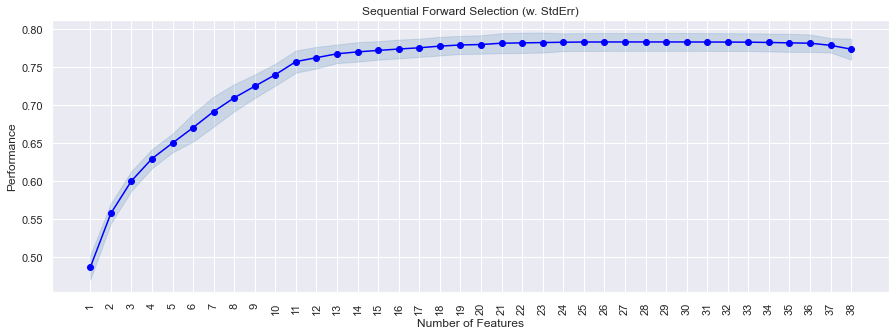

```python
# to plot the performance with addition of each feature
from mlxtend.plotting import plot_sequential_feature_selection as plot_sfs

fig1 = plot_sfs(sfs.get_metric_dict(), kind="std_err", figsize=(15, 5))
plt.title("Sequential Forward Selection (w. StdErr)")
plt.xticks(rotation=90)
plt.show()
```

```python
# Let us select features which are important
feat_cols = list(sfs.k_feature_idx_)
print(feat_cols)
```

```
[0, 1, 2, 3, 4, 5, 6, 7, 8, 9, 10, 11, 12, 13, 14, 15, 16, 17, 18, 19, 20, 21, 22, 23, 24, 25, 26, 27, 28, 29, 30, 31, 32, 33, 34, 35, 36, 37]
```

### Trying with PolynomialFeatures

We will try with PolynomialFeatures to see if that gives a better $R^2$ value. If there are interdependencies among independent variable PolynomialFeatures may give a better $R^2$ value. But it may overfit as we are increasing the number of features significantly.

```python
#Adding interaction terms

from sklearn.preprocessing import PolynomialFeatures
from sklearn import linear_model

poly = PolynomialFeatures(degree=2, interaction_only=True)
X1_train2 = poly.fit_transform(X1_train)
X1_test2 = poly.fit_transform(X1_test)

poly_clf = linear_model.LinearRegression()

poly_clf.fit(X1_train2, y1_train)

#In sample (training) R^2 will always improve with the number of variables!
print(poly_clf.score(X1_train2, y1_train))
```

```
0.9379128563161803
```

> PolynomialFeatures is able to explain almost 94% of a variation in the training data, which is really good!

```python
# Now check on the test set for PolynomialFeatures
print(poly_clf.score(X1_test2, y1_test))
```

```
-3.258035067548068
```

```python
# but this improves as the cost of 29 extra variables!
print(X1_train.shape)
print(X1_train2.shape)
```

```
(4213, 38)
(4213, 742)
```

> - Although PolynomialFeatures did really well in the training set but it is not usable for Test set at all
> - PolynomialFeatures produced a overfit model with 742 features
> - It is of no use and we are going to discard it.

## Trying with dropping Name and Location features

We noticed that Car Names or its Brand name and model did play a role but in this exercise we will see if we discard these descriptive columns if we can get a comparable $R^2$ value.

```python
# Model Building without BM_Range and Med_Price_Zone i.e. Name and Locations
X2 = df.drop(["Price", "BM_Range", "Med_Price_Zone"], axis=1)
y2 = df["Price"]
```

```python
# Creating Dummy Variables
X2 = pd.get_dummies(
    X2,
    columns=X2.select_dtypes(include=["object", "category"]).columns.tolist(),
    drop_first=True,
)

X2.head()
```

|  | Seats | Mileage_Num | Years_Old | KM_Driven_Std | Power_Log | Fuel_Type_Diesel | Fuel_Type_Electric | Fuel_Type_LPG | Fuel_Type_Petrol | Transmission_Manual | Owner_Type_Fourth & Above | Owner_Type_Second | Owner_Type_Third |
| --- | --- | --- | --- | --- | --- | --- | --- | --- | --- | --- | --- | --- | --- |
| 0 | 5.0 | 0.744289 | 11 | 0.390350 | 4.063198 | 0 | 0 | 0 | 0 | 1 | 0 | 0 | 0 |
| 1 | 5.0 | 0.488946 | 6 | -0.452290 | 4.837868 | 1 | 0 | 0 | 0 | 1 | 0 | 0 | 0 |
| 2 | 5.0 | 0.434783 | 10 | -0.316380 | 4.485260 | 0 | 0 | 0 | 1 | 1 | 0 | 0 | 0 |
| 3 | 7.0 | 0.529477 | 9 | 0.798079 | 4.485936 | 1 | 0 | 0 | 0 | 1 | 0 | 0 | 0 |
| 4 | 5.0 | 0.324245 | 8 | -0.461260 | 4.947340 | 1 | 0 | 0 | 0 | 0 | 0 | 1 | 0 |

```python
X2_train, X2_test, y2_train, y2_test = train_test_split(X2, y2, test_size=0.3, random_state=1);
```

```python
print('Shape of X2_train: ', X2_train.shape)
print('Shape of X2_test: ', X2_test.shape)
```

```
Shape of X2_train:  (4213, 13)
Shape of X2_test:  (1806, 13)
```

> We will be running the model with only 13 features instead of 38 in the previous case. This is a very simplified model.

```python
lin_reg_model2 = LinearRegression()
lin_reg_model2.fit(X2_train, y2_train);
coef_df2 = pd.DataFrame(
    np.append(lin_reg_model2.coef_, lin_reg_model2.intercept_),
    index=X2_train.columns.tolist() + ["Intercept"],
    columns=["Coefficients"],
)
coef_df2.sort_values(by='Coefficients')
```

|  | Coefficients |
| --- | --- |
| Intercept | -23.521202 |
| Mileage_Num | -11.348179 |
| Fuel_Type_Petrol | -5.786504 |
| Transmission_Manual | -4.059953 |
| Fuel_Type_Diesel | -1.838173 |
| Seats | -1.416186 |
| KM_Driven_Std | -1.184389 |
| Years_Old | -0.839700 |
| Fuel_Type_LPG | -0.418388 |
| Owner_Type_Second | -0.330174 |
| Owner_Type_Third | 1.595156 |
| Fuel_Type_Electric | 2.196914 |
| Owner_Type_Fourth & Above | 2.327905 |
| Power_Log | 12.604839 |

```python
# Checking model performance on train set
print("--- Training Performance without Car Names and Models ---")
lgm2_train_perf = model_perf_report(lin_reg_model2, X2_train, y2_train)
lgm2_train_perf
```

```
--- Training Performance without Car Names and Models ---
```

|  | RMSE | MAE | R-squared | Adj. R-squared |
| --- | --- | --- | --- | --- |
| 0 | 7.097667 | 4.312384 | 0.606022 | 0.604802 |

```python
# Checking model performance on train set
print("--- Test Performance without Car Names and Models ---")
lgm2_test_perf = model_perf_report(lin_reg_model2, X2_test, y2_test)
lgm2_test_perf
```

```
--- Test Performance without Car Names and Models ---
```

|  | RMSE | MAE | R-squared | Adj. R-squared |
| --- | --- | --- | --- | --- |
| 0 | 6.336995 | 4.123638 | 0.661844 | 0.659391 |

> - We can see $R^2$ is 0.66 for Test set which means only 66% of the variation can be explained in this case.
> - RMSE is also higher compared with previous LinerRegression Model with 38 feature
> - We are better off with 38 features instead of 13.

```python
# Checking the same 13 features with PolynomialFeatures

poly2 = PolynomialFeatures(degree=2, interaction_only=True)
X2_train2 = poly2.fit_transform(X2_train)
X2_test2 = poly2.fit_transform(X2_test)

poly_clf2 = linear_model.LinearRegression()

poly_clf2.fit(X2_train2, y2_train)

#In sample (training) R^2 will always improve with the number of variables!
print(poly_clf2.score(X2_train2, y2_train))
```

```
0.8173407690432553
```

```python
print(poly_clf2.score(X2_test2, y2_test))
```

```
0.8117832814369905
```

```python
# but this improves as the cost of 29 extra variables!
print(X2_train.shape)
print(X2_train2.shape)
```

```
(4213, 13)
(4213, 92)
```

```python
# Checking model performance on train set
print("Test Performance without Car Names and Models (Polynomial Features)")
lgm2_test_perf2 = model_perf_report(poly_clf2, X2_test2, y2_test)
lgm2_test_perf2
```

```
Test Performance without Car Names and Models (Polynomial Features)
```

|  | RMSE | MAE | R-squared | Adj. R-squared |
| --- | --- | --- | --- | --- |
| 0 | 4.727742 | 2.6016 | 0.811783 | 0.801675 |

> - Interestingly this time with only 13 features PolynomialFeatures model achieved $R^2$ of 0.81
> - It is almost comparable to the LinerRegression model with 38 features
> - So if we do not want to use Name and Location due to complexities then this model will perform best

## Comparision of Model Performance

We tried verious features and models and here is a summary of them which are worthy of consideration.

```python
# test performance comparison
models_test_comp_df2 = pd.concat(
    [lgm_test_perf.T, lgm2_test_perf.T, lgm2_test_perf2.T],
    axis=1,
)

models_test_comp_df2.columns = [
    "LinerRegression with all Features",
    "LinerRegression w/o Name/Location",
    "LinerRegression with PolynomialFeatures w/o Names/Location"
]

print("Test performance comparison:")
models_test_comp_df2.T.sort_values(by='R-squared', ascending=False)
```

```
Test performance comparison:
```

|  | RMSE | MAE | R-squared | Adj. R-squared |
| --- | --- | --- | --- | --- |
| LinerRegression with all Features | 4.640948 | 2.481522 | 0.818631 | 0.814730 |
| LinerRegression with PolynomialFeatures w/o Names/Location | 4.727742 | 2.601600 | 0.811783 | 0.801675 |
| LinerRegression w/o Name/Location | 6.336995 | 4.123638 | 0.661844 | 0.659391 |

## Conclusions

- With the given features used_cars_data.csv it is possible to build a Supervised Learning model that can predict the price of a pre-owned cars with $R^2$ value of 0.81.
- If a simplar model is desired that does not include car Names and Locations due to space time complexity then a Liner Regression model with Polynomial Features would be best.
- But if space time complexity is not an issue then we need to feature engineer Name and Locations and use a simple LinerRegression model.
- In order to increase the performance of the models more data need to be collected which can give more quantititive information on the model variant and the condition of the car.
- Features such as Safety Rating, Leather Seats, Car Electronics features, Condition Rating (Mechanical/Body) etc. need to be added and then models can be trained to better predit the price.
- But it seems with right feature sets LinerRegression can predict pre-owned car prices with very good accuracy. And Cars4U can improve its car pricing and efficiency with these type of predictive model. Which can bring efficiency in the system, reduce cost and improve sales and operating profit to a great extent!